fossil

# Gene-disease networks, dug back up.

Navlakha and Kingsford released their predictions but not their code. We rebuilt the methods from the paper, reran them on the same networks, and compared every number the paper prints or draws. 2 of 19 attempted results came back exactly, 13 agree, 4 partly agree and 0 differ; 6 were not attempted.

See every result

## Install diseasenet

Python package

```
pip install "git+https://github.com/jeonglab-bcm/fossil#subdirectory=PMC2853684/package"
```

Python 3.10 or later, with numpy and scipy.

[README](https://github.com/jeonglab-bcm/fossil/blob/main/PMC2853684/package/README.md) [Tutorial](https://github.com/jeonglab-bcm/fossil/blob/main/PMC2853684/package/tutorial/TUTORIAL.md)

## Fig. 2a

Fig. 2a. Precision and recall of the 13 methods and the consensus on HPRD, leave-one-out, over each method's thresholds.

Partly agrees

Published

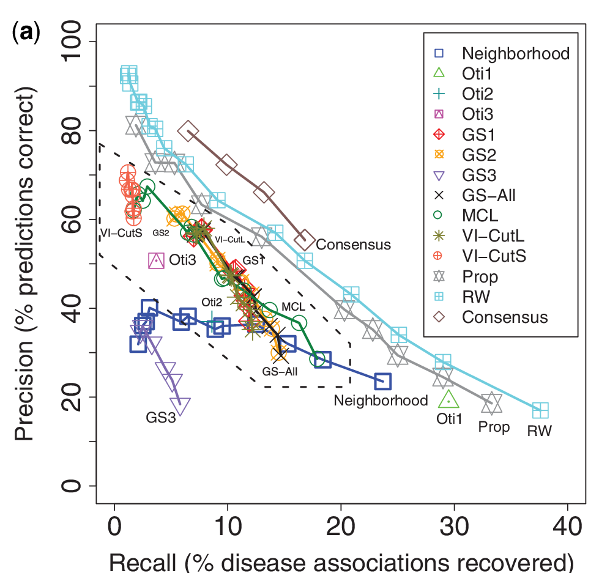

Our run on the published figure

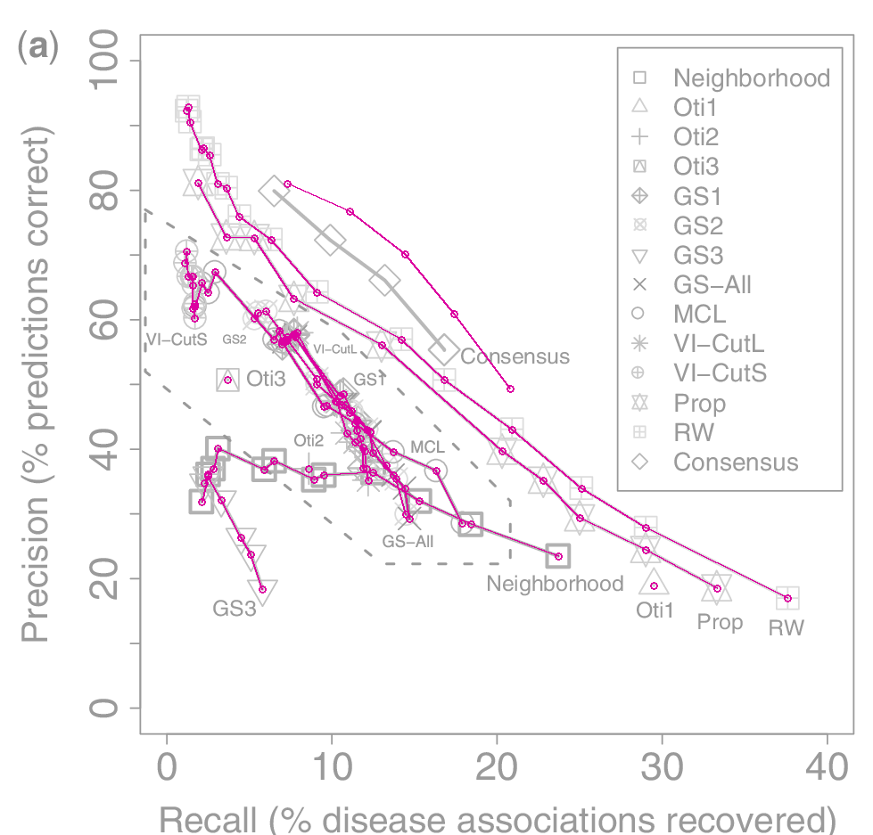

**Fig. 2a, precision and recall of the 13 methods on HPRD**

235 of 237 values, Partly agrees

**Fig. 2a, consensus Random Forest (5 points)**

1 of 11 values, Partly agrees

## Fig. 2b

Fig. 2b. The clustering methods of Fig. 2a, magnified.

Partly agrees

Published

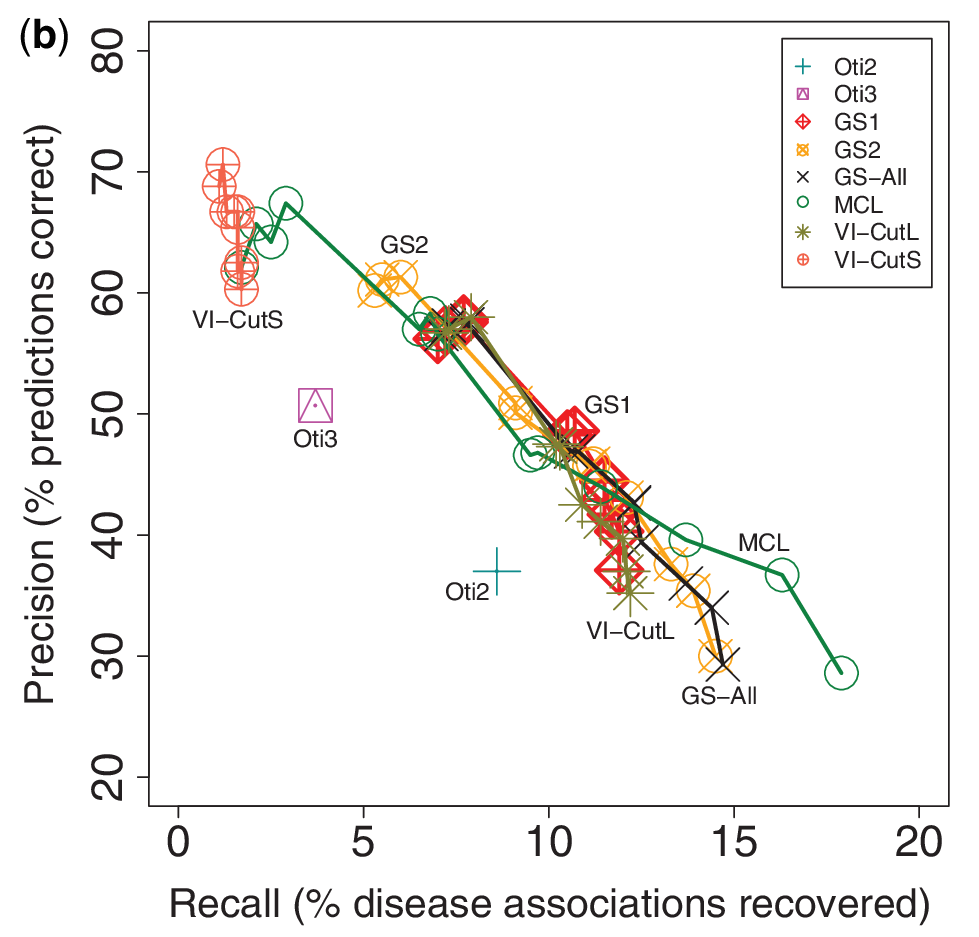

Our run on the published figure

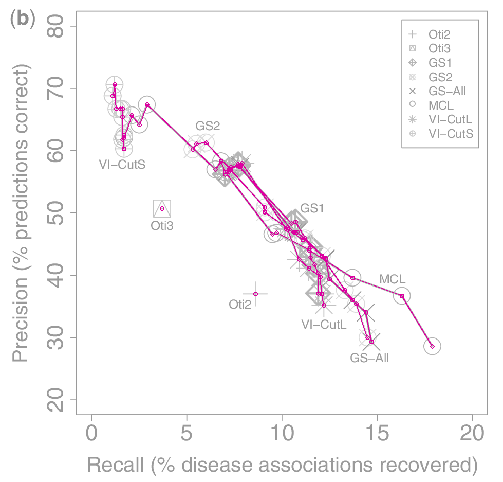

**Fig. 2b, the clustering methods magnified**

138 of 140 values, Partly agrees

As Fig. 2a: every drawn point comes back; GS1 (11.5, 44.4) and VI-CutS (1.6, 65.4), (1.5, 66.7) are ours only.

## Fig. 3

Fig. 3. Diseases by their maximum precision (rows) and maximum recall (columns) over the 13 methods, at thresholds near 10% recall; row and column sums at the margins.

Agrees

Published

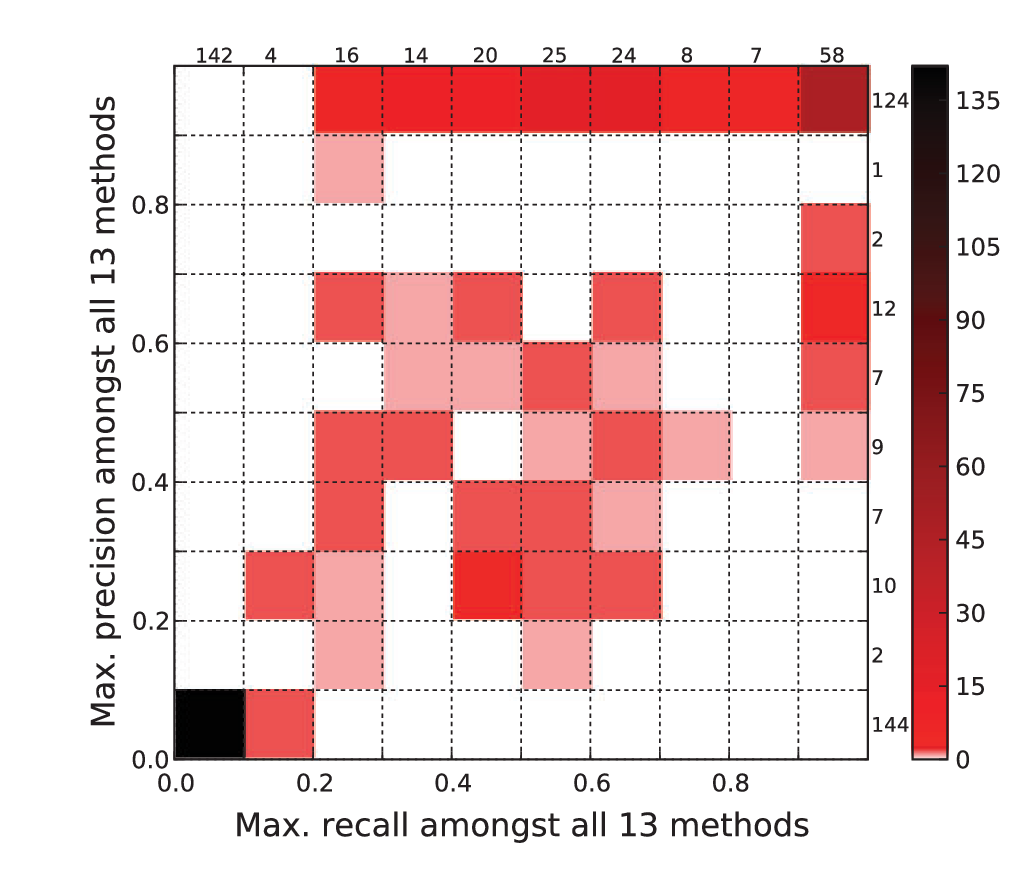

Our run on the published figure

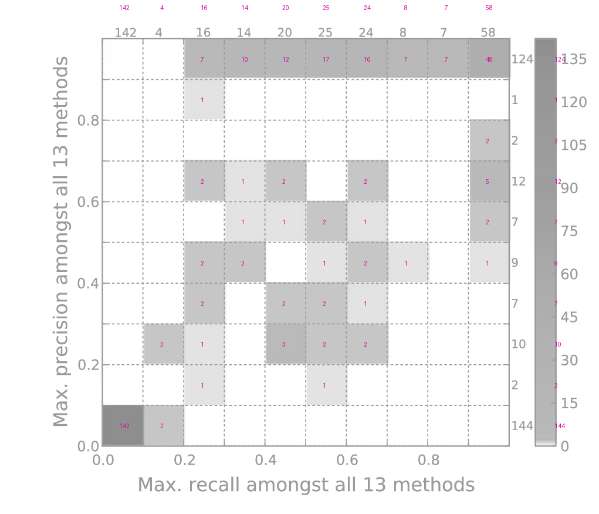

**Fig. 3, diseases by maximum precision and recall (row and column sums)**

20 of 20 values, Agrees

## Fig. 4a

Fig. 4a. F1 of the predictions for each disease against its neighbourhood homophily, for five methods; bars are means, error bars variances, lines least-squares fits with Pearson r in the legend.

Agrees

Published

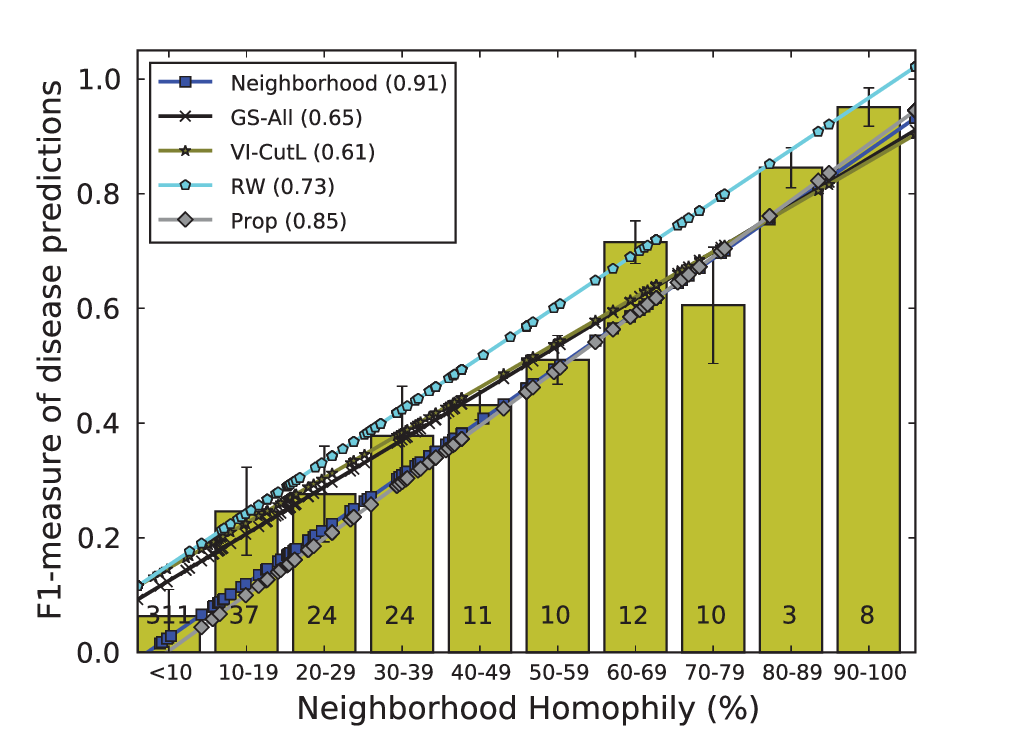

Our run on the published figure

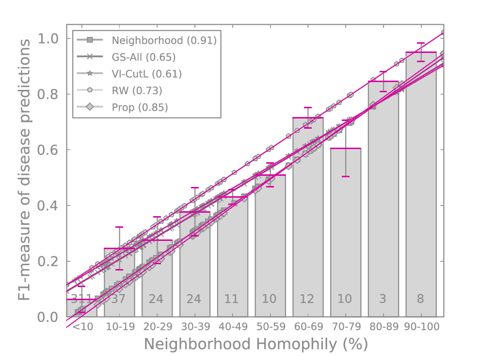

**Fig. 4a, F1 against neighbourhood homophily**

45 of 45 values, Agrees

## Fig. 4b

Fig. 4b. The same against the average pairwise distance between the disease's genes.

Agrees

Published

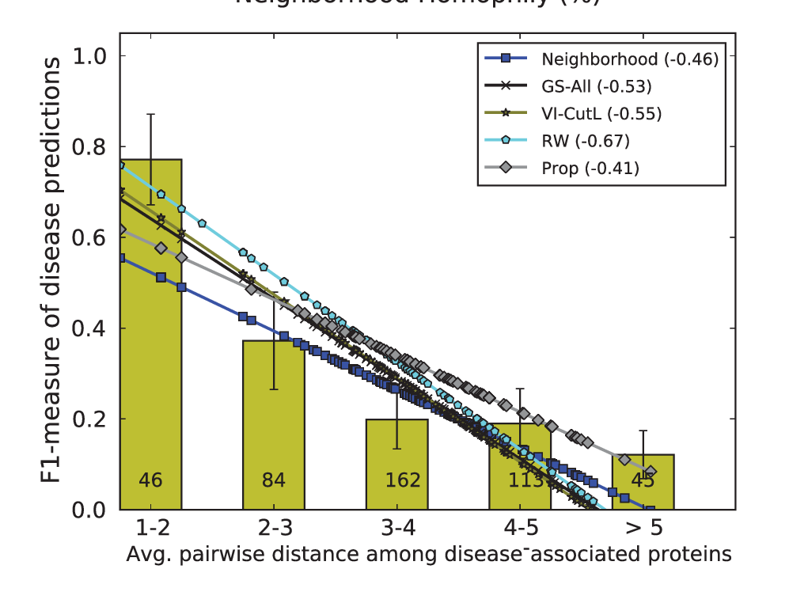

Our run on the published figure

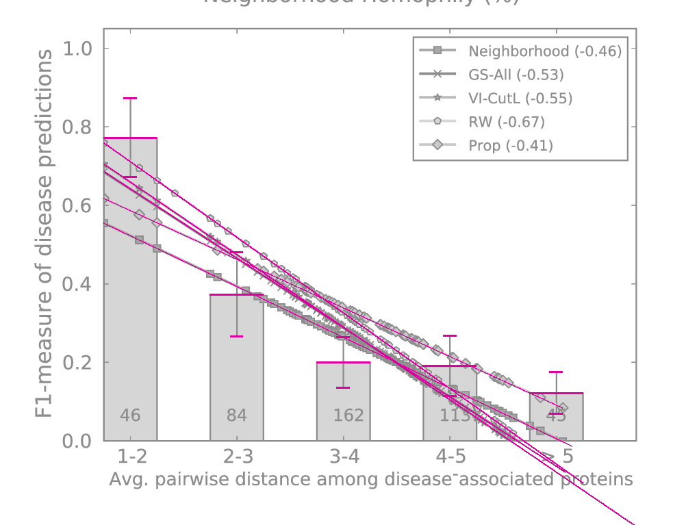

**Fig. 4b, F1 against average pairwise distance**

30 of 30 values, Agrees

## Supp. Fig. S1

Supp. Fig. S1. Precision and recall of the 13 methods on OPHID.

Agrees

Published

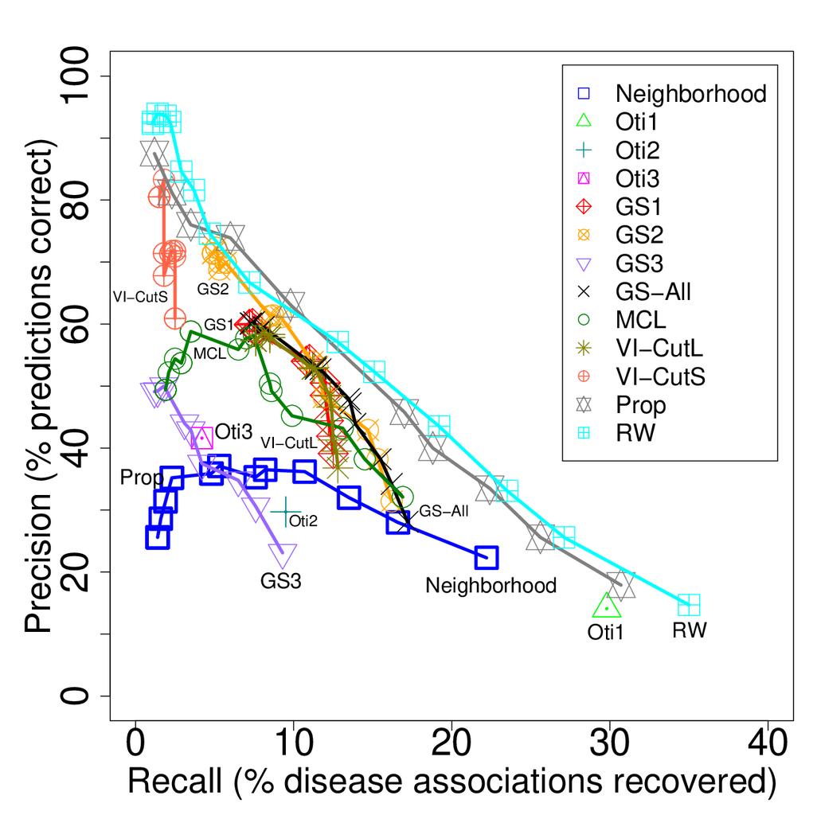

Our run on the published figure

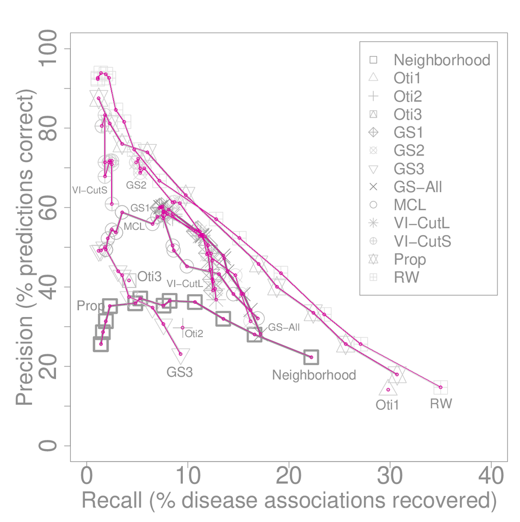

**Supp. Fig. S1, precision and recall on OPHID**

353 of 353 values, Agrees

## Supp. Fig. S2

Supp. Fig. S2. Precision (left) and recall (right) against neighbourhood homophily (top) and average pairwise distance (bottom).

Agrees

Published

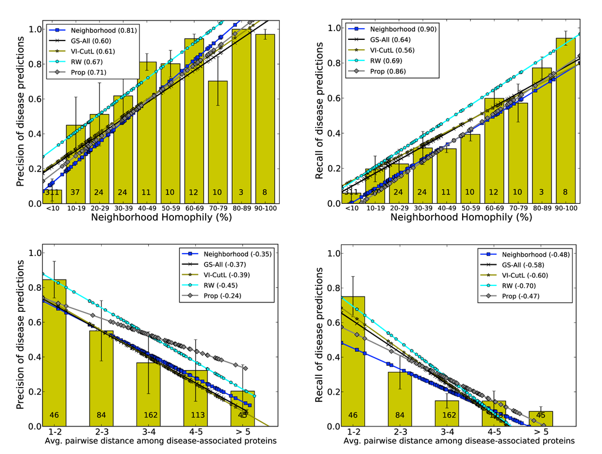

Our run on the published figure

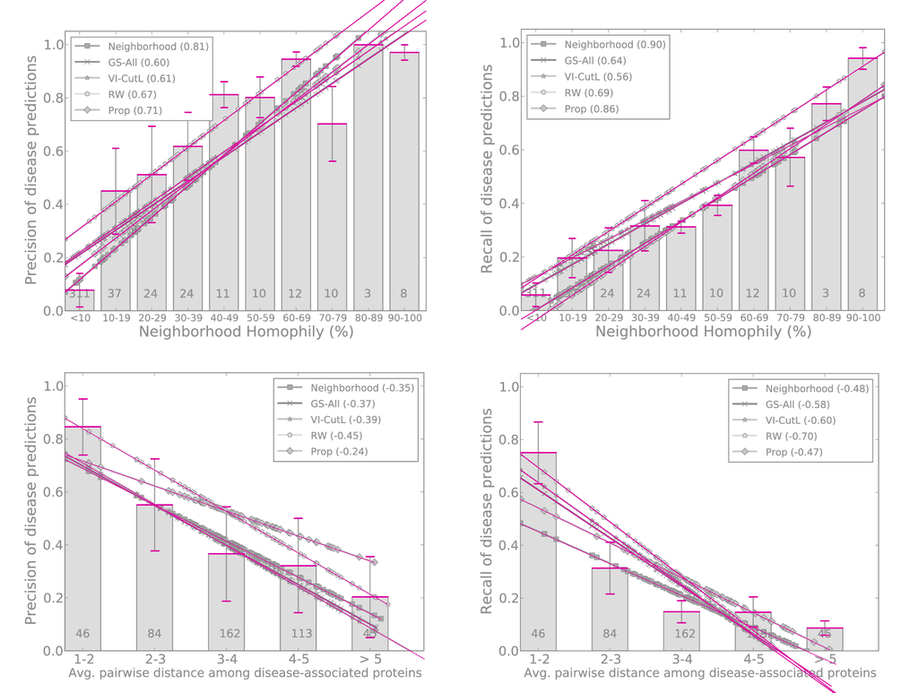

**Supp. Fig. S2, precision and recall against homophily**

141 of 141 values, Agrees

## Every result

Every figure, table and number of the paper, with the verdict check_results.py computes from our run. Figure values are read from the vector drawings in the paper's PDF.

Result

Verdict

Measure

Why

Table 1 (the methods compared)

Not attempted

A list of the methods, not a computed result.

Fig. 1 (leave-one-out scheme)

Not attempted

A schematic of the testing framework.

Sec. 2.1, network and annotation counts

Exact

11 of 11 values

- HPRD main component, proteins: paper 8776, ours **8776**
- HPRD main component, interactions: paper 35820, ours **35820**
- OPHID proteins: paper 9842, ours **9842**
- OPHID interactions: paper 73130, ours **73130**
- genes with a locus: paper 8470, ours **8470**
- annotated genes: paper 1415, ours **1415**
- diseases: paper 450, ours **450**
- genes per disease: paper 4.60, ours **4.60**
- diseases per gene: paper 1.46, ours **1.46**
- genes in a disease's intervals: paper 397, ours **397**
- unannotated genes: paper 7361, ours **7361**

Sec. 2.1, the whole HPRD network (9182 proteins, 36 169 interactions)

Not attempted

The paper's site distributed only the main component (HPRD.net: 8,776 proteins, 35,820 interactions); HPRD Release 7 itself is no longer distributed.

Sec. 2.1, 189 genes outside their disease's intervals

Not attempted

Needs the 2008 UniProt gene loci, which were not distributed; the candidate file already holds every gene in an interval of its disease, with the 189 assigned.

Methods rerun from the paper's text against the authors' prediction files

Agrees

Fig. 2a, precision and recall of the 13 methods on HPRD

Partly agrees

235 of 237 values

- Neighborhood point 1 recall: paper 23.7, ours **23.7**
- Neighborhood point 1 precision: paper 23.5, ours **23.5**
- Neighborhood point 2 recall: paper 18.4, ours **18.4**
- Neighborhood point 2 precision: paper 28.4, ours **28.4**
- Neighborhood point 3 recall: paper 15.3, ours **15.3**
- Neighborhood point 3 precision: paper 32.0, ours **32.0**
- Neighborhood point 4 recall: paper 12.5, ours **12.5**
- Neighborhood point 4 precision: paper 36.4, ours **36.4**
- Neighborhood point 5 recall: paper 9.5, ours **9.5**
- Neighborhood point 5 precision: paper 36.0, ours **36.0**
- Neighborhood point 6 recall: paper 8.9, ours **8.9**
- Neighborhood point 6 precision: paper 35.3, ours **35.3**
- Neighborhood point 7 recall: paper 6.5, ours **6.5**
- Neighborhood point 7 precision: paper 38.2, ours **38.2**
- Neighborhood point 8 recall: paper 5.9, ours **5.9**
- Neighborhood point 8 precision: paper 36.9, ours **36.9**
- Neighborhood point 9 recall: paper 3.1, ours **3.1**
- Neighborhood point 9 precision: paper 40.1, ours **40.1**
- Neighborhood point 10 recall: paper 2.8, ours **2.8**
- Neighborhood point 10 precision: paper 37.0, ours **37.0**
- Neighborhood point 11 recall: paper 2.5, ours **2.5**
- Neighborhood point 11 precision: paper 36.1, ours **36.1**
- Neighborhood point 12 recall: paper 2.1, ours **2.1**
- Neighborhood point 12 precision: paper 31.9, ours **31.9**
- Neighborhood points drawn: paper 12, ours **12**
- Oti1 point 1 recall: paper 29.5, ours **29.5**
- Oti1 point 1 precision: paper 19.0, ours **19.0**
- Oti1 points drawn: paper 1, ours **1**
- Oti2 point 1 recall: paper 8.6, ours **8.6**
- Oti2 point 1 precision: paper 37.0, ours **37.0**
- Oti2 points drawn: paper 1, ours **1**
- Oti3 point 1 recall: paper 3.7, ours **3.7**
- Oti3 point 1 precision: paper 50.7, ours **50.7**
- Oti3 points drawn: paper 1, ours **1**
- GS1 point 1 recall: paper 11.9, ours **11.9**
- GS1 point 1 precision: paper 37.1, ours **37.1**
- GS1 point 2 recall: paper 11.9, ours **11.9**
- GS1 point 2 precision: paper 40.3, ours **40.3**
- GS1 point 3 recall: paper 11.7, ours **11.7**
- GS1 point 3 precision: paper 41.7, ours **41.7**
- GS1 point 4 recall: paper 11.5, ours **11.5**
- GS1 point 4 precision: paper 42.9, ours **42.9**
- GS1 point 5 recall: paper 11.5, ours **11.5**
- GS1 point 5 precision: paper 44.5, ours **44.5**
- GS1 point 6 recall: paper 10.7, ours **10.7**
- GS1 point 6 precision: paper 48.6, ours **48.6**
- GS1 point 7 recall: paper 10.5, ours **10.5**
- GS1 point 7 precision: paper 48.3, ours **48.3**
- GS1 point 8 recall: paper 7.7, ours **7.7**
- GS1 point 8 precision: paper 57.6, ours **57.6**
- GS1 point 9 recall: paper 7.7, ours **7.7**
- GS1 point 9 precision: paper 57.8, ours **57.8**
- GS1 point 10 recall: paper 7.2, ours **7.2**
- GS1 point 10 precision: paper 56.9, ours **56.9**
- GS1 point 11 recall: paper 7.0, ours **7.0**
- GS1 point 11 precision: paper 56.2, ours **56.2**
- GS1 points drawn: paper 11, ours **12**
- GS2 point 1 recall: paper 14.5, ours **14.5**
- GS2 point 1 precision: paper 30.0, ours **30.0**
- GS2 point 2 recall: paper 13.9, ours **13.9**
- GS2 point 2 precision: paper 35.4, ours **35.4**
- GS2 point 3 recall: paper 13.3, ours **13.3**
- GS2 point 3 precision: paper 37.6, ours **37.6**
- GS2 point 4 recall: paper 12.1, ours **12.1**
- GS2 point 4 precision: paper 43.1, ours **43.1**
- GS2 point 5 recall: paper 11.2, ours **11.2**
- GS2 point 5 precision: paper 45.9, ours **45.9**
- GS2 point 6 recall: paper 11.1, ours **11.1**
- GS2 point 6 precision: paper 45.7, ours **45.7**
- GS2 point 7 recall: paper 9.1, ours **9.1**
- GS2 point 7 precision: paper 50.1, ours **50.1**
- GS2 point 8 recall: paper 9.1, ours **9.1**
- GS2 point 8 precision: paper 50.9, ours **50.9**
- GS2 point 9 recall: paper 6.0, ours **6.0**
- GS2 point 9 precision: paper 61.3, ours **61.3**
- GS2 point 10 recall: paper 5.5, ours **5.5**
- GS2 point 10 precision: paper 61.1, ours **61.1**
- GS2 point 11 recall: paper 5.3, ours **5.3**
- GS2 point 11 precision: paper 60.2, ours **60.2**
- GS2 points drawn: paper 11, ours **11**
- GS3 point 1 recall: paper 5.8, ours **5.8**
- GS3 point 1 precision: paper 18.4, ours **18.4**
- GS3 point 2 recall: paper 5.1, ours **5.1**
- GS3 point 2 precision: paper 23.8, ours **23.8**
- GS3 point 3 recall: paper 4.5, ours **4.5**
- GS3 point 3 precision: paper 26.4, ours **26.4**
- GS3 point 4 recall: paper 3.3, ours **3.3**
- GS3 point 4 precision: paper 32.2, ours **32.2**
- GS3 point 5 recall: paper 2.5, ours **2.5**
- GS3 point 5 precision: paper 35.9, ours **35.9**
- GS3 point 6 recall: paper 2.3, ours **2.3**
- GS3 point 6 precision: paper 34.8, ours **34.8**
- GS3 points drawn: paper 6, ours **6**
- GS-All point 1 recall: paper 14.7, ours **14.7**
- GS-All point 1 precision: paper 29.3, ours **29.3**
- GS-All point 2 recall: paper 14.4, ours **14.4**
- GS-All point 2 precision: paper 34.0, ours **34.0**
- GS-All point 3 recall: paper 13.7, ours **13.7**
- GS-All point 3 precision: paper 36.0, ours **36.0**
- GS-All point 4 recall: paper 12.5, ours **12.5**
- GS-All point 4 precision: paper 39.4, ours **39.4**
- GS-All point 5 recall: paper 12.3, ours **12.3**
- GS-All point 5 precision: paper 42.6, ours **42.6**
- GS-All point 6 recall: paper 12.3, ours **12.3**
- GS-All point 6 precision: paper 42.7, ours **42.7**
- GS-All point 7 recall: paper 10.8, ours **10.8**
- GS-All point 7 precision: paper 46.9, ours **46.9**
- GS-All point 8 recall: paper 10.6, ours **10.6**
- GS-All point 8 precision: paper 46.9, ours **46.9**
- GS-All point 9 recall: paper 7.8, ours **7.8**
- GS-All point 9 precision: paper 57.4, ours **57.4**
- GS-All point 10 recall: paper 7.8, ours **7.8**
- GS-All point 10 precision: paper 57.7, ours **57.7**
- GS-All point 11 recall: paper 7.3, ours **7.3**
- GS-All point 11 precision: paper 57.3, ours **57.3**
- GS-All point 12 recall: paper 7.1, ours **7.1**
- GS-All point 12 precision: paper 56.6, ours **56.6**
- GS-All points drawn: paper 12, ours **12**
- MCL point 1 recall: paper 17.9, ours **17.9**
- MCL point 1 precision: paper 28.6, ours **28.6**
- MCL point 2 recall: paper 16.3, ours **16.3**
- MCL point 2 precision: paper 36.7, ours **36.7**
- MCL point 3 recall: paper 13.7, ours **13.7**
- MCL point 3 precision: paper 39.6, ours **39.6**
- MCL point 4 recall: paper 11.4, ours **11.4**
- MCL point 4 precision: paper 44.0, ours **44.0**
- MCL point 5 recall: paper 9.7, ours **9.7**
- MCL point 5 precision: paper 46.8, ours **46.8**
- MCL point 6 recall: paper 9.5, ours **9.5**
- MCL point 6 precision: paper 46.6, ours **46.6**
- MCL point 7 recall: paper 7.0, ours **7.0**
- MCL point 7 precision: paper 56.6, ours **56.6**
- MCL point 8 recall: paper 6.8, ours **6.8**
- MCL point 8 precision: paper 58.3, ours **58.3**
- MCL point 9 recall: paper 6.5, ours **6.5**
- MCL point 9 precision: paper 57.0, ours **57.0**
- MCL point 10 recall: paper 2.9, ours **2.9**
- MCL point 10 precision: paper 67.4, ours **67.4**
- MCL point 11 recall: paper 2.5, ours **2.5**
- MCL point 11 precision: paper 64.2, ours **64.2**
- MCL point 12 recall: paper 2.1, ours **2.1**
- MCL point 12 precision: paper 65.7, ours **65.7**
- MCL point 13 recall: paper 1.7, ours **1.7**
- MCL point 13 precision: paper 62.1, ours **62.1**
- MCL points drawn: paper 13, ours **13**
- VI-CutL point 1 recall: paper 12.2, ours **12.2**
- VI-CutL point 1 precision: paper 35.2, ours **35.2**
- VI-CutL point 2 recall: paper 12.1, ours **12.1**
- VI-CutL point 2 precision: paper 37.0, ours **37.0**
- VI-CutL point 3 recall: paper 12.0, ours **12.0**
- VI-CutL point 3 precision: paper 39.7, ours **39.7**
- VI-CutL point 4 recall: paper 11.4, ours **11.4**
- VI-CutL point 4 precision: paper 41.1, ours **41.1**
- VI-CutL point 5 recall: paper 10.9, ours **10.9**
- VI-CutL point 5 precision: paper 42.5, ours **42.5**
- VI-CutL point 6 recall: paper 10.3, ours **10.3**
- VI-CutL point 6 precision: paper 47.3, ours **47.3**
- VI-CutL point 7 recall: paper 10.2, ours **10.2**
- VI-CutL point 7 precision: paper 47.5, ours **47.5**
- VI-CutL point 8 recall: paper 7.9, ours **7.9**
- VI-CutL point 8 precision: paper 58.0, ours **58.0**
- VI-CutL point 9 recall: paper 7.3, ours **7.3**
- VI-CutL point 9 precision: paper 57.0, ours **57.0**
- VI-CutL point 10 recall: paper 7.2, ours **7.2**
- VI-CutL point 10 precision: paper 56.7, ours **56.7**
- VI-CutL points drawn: paper 10, ours **10**
- VI-CutS point 1 recall: paper 1.7, ours **1.7**
- VI-CutS point 1 precision: paper 60.3, ours **60.3**
- VI-CutS point 2 recall: paper 1.7, ours **1.7**
- VI-CutS point 2 precision: paper 62.5, ours **62.5**
- VI-CutS point 3 recall: paper 1.6, ours **1.6**
- VI-CutS point 3 precision: paper 61.8, ours **61.8**
- VI-CutS point 4 recall: paper 1.6, ours **1.6**
- VI-CutS point 4 precision: paper 66.7, ours **66.7**
- VI-CutS point 5 recall: paper 1.3, ours **1.3**
- VI-CutS point 5 precision: paper 66.7, ours **66.7**
- VI-CutS point 6 recall: paper 1.2, ours **1.2**
- VI-CutS point 6 precision: paper 70.6, ours **70.6**
- VI-CutS point 7 recall: paper 1.1, ours **1.1**
- VI-CutS point 7 precision: paper 68.8, ours **68.8**
- VI-CutS points drawn: paper 7, ours **9**
- Prop point 1 recall: paper 33.3, ours **33.3**
- Prop point 1 precision: paper 18.6, ours **18.6**
- Prop point 2 recall: paper 29.0, ours **29.0**
- Prop point 2 precision: paper 24.5, ours **24.5**
- Prop point 3 recall: paper 25.0, ours **25.0**
- Prop point 3 precision: paper 29.4, ours **29.4**
- Prop point 4 recall: paper 22.8, ours **22.8**
- Prop point 4 precision: paper 35.2, ours **35.2**
- Prop point 5 recall: paper 20.3, ours **20.3**
- Prop point 5 precision: paper 39.7, ours **39.7**
- Prop point 6 recall: paper 13.0, ours **13.0**
- Prop point 6 precision: paper 56.1, ours **56.1**
- Prop point 7 recall: paper 7.7, ours **7.7**
- Prop point 7 precision: paper 63.3, ours **63.3**
- Prop point 8 recall: paper 5.3, ours **5.3**
- Prop point 8 precision: paper 72.7, ours **72.7**
- Prop point 9 recall: paper 3.6, ours **3.6**
- Prop point 9 precision: paper 72.8, ours **72.8**
- Prop point 10 recall: paper 1.9, ours **1.9**
- Prop point 10 precision: paper 81.2, ours **81.2**
- Prop points drawn: paper 10, ours **10**
- RW point 1 recall: paper 37.6, ours **37.6**
- RW point 1 precision: paper 17.0, ours **17.0**
- RW point 2 recall: paper 29.0, ours **29.0**
- RW point 2 precision: paper 27.9, ours **27.9**
- RW point 3 recall: paper 25.1, ours **25.1**
- RW point 3 precision: paper 34.0, ours **34.0**
- RW point 4 recall: paper 20.9, ours **20.9**
- RW point 4 precision: paper 43.1, ours **43.1**
- RW point 5 recall: paper 16.8, ours **16.8**
- RW point 5 precision: paper 50.7, ours **50.7**
- RW point 6 recall: paper 14.2, ours **14.2**
- RW point 6 precision: paper 57.0, ours **57.0**
- RW point 7 recall: paper 9.1, ours **9.1**
- RW point 7 precision: paper 64.3, ours **64.3**
- RW point 8 recall: paper 6.3, ours **6.3**
- RW point 8 precision: paper 72.4, ours **72.4**
- RW point 9 recall: paper 4.4, ours **4.4**
- RW point 9 precision: paper 76.0, ours **76.0**
- RW point 10 recall: paper 3.6, ours **3.6**
- RW point 10 precision: paper 80.4, ours **80.4**
- RW point 11 recall: paper 3.1, ours **3.1**
- RW point 11 precision: paper 81.0, ours **81.0**
- RW point 12 recall: paper 2.6, ours **2.6**
- RW point 12 precision: paper 85.5, ours **85.5**
- RW point 13 recall: paper 2.2, ours **2.2**
- RW point 13 precision: paper 86.5, ours **86.5**
- RW point 14 recall: paper 2.1, ours **2.1**
- RW point 14 precision: paper 86.3, ours **86.3**
- RW point 15 recall: paper 1.4, ours **1.4**
- RW point 15 precision: paper 90.6, ours **90.6**
- RW point 16 recall: paper 1.3, ours **1.3**
- RW point 16 precision: paper 92.9, ours **92.9**
- RW point 17 recall: paper 1.2, ours **1.2**
- RW point 17 precision: paper 92.3, ours **92.3**
- RW points drawn: paper 17, ours **17**

Every point the paper draws comes back, but our curves have 3 points the figure leaves out: GS1 at theta 0.25 (11.5, 44.4) and VI-CutS at 0.25-0.3 (1.6, 65.4) and 0.4-0.45 (1.5, 66.7). The same thresholds are drawn for every other method, and Supp. Fig. S1 draws all 19 GS1 and VI-CutS points.

Fig. 2b, the clustering methods magnified

Partly agrees

138 of 140 values

- GS1 point 1 recall: paper 11.9, ours **11.9**
- GS1 point 1 precision: paper 37.1, ours **37.1**
- GS1 point 2 recall: paper 11.9, ours **11.9**
- GS1 point 2 precision: paper 40.3, ours **40.3**
- GS1 point 3 recall: paper 11.7, ours **11.7**
- GS1 point 3 precision: paper 41.7, ours **41.7**
- GS1 point 4 recall: paper 11.5, ours **11.5**
- GS1 point 4 precision: paper 42.9, ours **42.9**
- GS1 point 5 recall: paper 11.5, ours **11.5**
- GS1 point 5 precision: paper 44.5, ours **44.5**
- GS1 point 6 recall: paper 10.7, ours **10.7**
- GS1 point 6 precision: paper 48.6, ours **48.6**
- GS1 point 7 recall: paper 10.5, ours **10.5**
- GS1 point 7 precision: paper 48.3, ours **48.3**
- GS1 point 8 recall: paper 7.7, ours **7.7**
- GS1 point 8 precision: paper 57.6, ours **57.6**
- GS1 point 9 recall: paper 7.7, ours **7.7**
- GS1 point 9 precision: paper 57.8, ours **57.8**
- GS1 point 10 recall: paper 7.2, ours **7.2**
- GS1 point 10 precision: paper 56.9, ours **56.9**
- GS1 point 11 recall: paper 7.0, ours **7.0**
- GS1 point 11 precision: paper 56.2, ours **56.2**
- GS1 points drawn: paper 11, ours **12**
- Oti2 point 1 recall: paper 8.6, ours **8.6**
- Oti2 point 1 precision: paper 37.0, ours **37.0**
- Oti2 points drawn: paper 1, ours **1**
- Oti3 point 1 recall: paper 3.7, ours **3.7**
- Oti3 point 1 precision: paper 50.7, ours **50.7**
- Oti3 points drawn: paper 1, ours **1**
- GS2 point 1 recall: paper 14.5, ours **14.5**
- GS2 point 1 precision: paper 30.0, ours **30.0**
- GS2 point 2 recall: paper 13.9, ours **13.9**
- GS2 point 2 precision: paper 35.4, ours **35.4**
- GS2 point 3 recall: paper 13.3, ours **13.3**
- GS2 point 3 precision: paper 37.6, ours **37.6**
- GS2 point 4 recall: paper 12.1, ours **12.1**
- GS2 point 4 precision: paper 43.1, ours **43.1**
- GS2 point 5 recall: paper 11.2, ours **11.2**
- GS2 point 5 precision: paper 45.9, ours **45.9**
- GS2 point 6 recall: paper 11.1, ours **11.1**
- GS2 point 6 precision: paper 45.7, ours **45.7**
- GS2 point 7 recall: paper 9.1, ours **9.1**
- GS2 point 7 precision: paper 50.1, ours **50.1**
- GS2 point 8 recall: paper 9.1, ours **9.1**
- GS2 point 8 precision: paper 50.9, ours **50.9**
- GS2 point 9 recall: paper 6.0, ours **6.0**
- GS2 point 9 precision: paper 61.3, ours **61.3**
- GS2 point 10 recall: paper 5.5, ours **5.5**
- GS2 point 10 precision: paper 61.1, ours **61.1**
- GS2 point 11 recall: paper 5.3, ours **5.3**
- GS2 point 11 precision: paper 60.2, ours **60.2**
- GS2 points drawn: paper 11, ours **11**
- GS-All point 1 recall: paper 14.7, ours **14.7**
- GS-All point 1 precision: paper 29.3, ours **29.3**
- GS-All point 2 recall: paper 14.4, ours **14.4**
- GS-All point 2 precision: paper 34.0, ours **34.0**
- GS-All point 3 recall: paper 13.7, ours **13.7**
- GS-All point 3 precision: paper 36.0, ours **36.0**
- GS-All point 4 recall: paper 12.5, ours **12.5**
- GS-All point 4 precision: paper 39.4, ours **39.4**
- GS-All point 5 recall: paper 12.3, ours **12.3**
- GS-All point 5 precision: paper 42.6, ours **42.6**
- GS-All point 6 recall: paper 12.3, ours **12.3**
- GS-All point 6 precision: paper 42.7, ours **42.7**
- GS-All point 7 recall: paper 10.8, ours **10.8**
- GS-All point 7 precision: paper 46.9, ours **46.9**
- GS-All point 8 recall: paper 10.6, ours **10.6**
- GS-All point 8 precision: paper 46.9, ours **46.9**
- GS-All point 9 recall: paper 7.8, ours **7.8**
- GS-All point 9 precision: paper 57.4, ours **57.4**
- GS-All point 10 recall: paper 7.8, ours **7.8**
- GS-All point 10 precision: paper 57.7, ours **57.7**
- GS-All point 11 recall: paper 7.3, ours **7.3**
- GS-All point 11 precision: paper 57.3, ours **57.3**
- GS-All point 12 recall: paper 7.1, ours **7.1**
- GS-All point 12 precision: paper 56.6, ours **56.6**
- GS-All points drawn: paper 12, ours **12**
- MCL point 1 recall: paper 17.9, ours **17.9**
- MCL point 1 precision: paper 28.6, ours **28.6**
- MCL point 2 recall: paper 16.3, ours **16.3**
- MCL point 2 precision: paper 36.7, ours **36.7**
- MCL point 3 recall: paper 13.7, ours **13.7**
- MCL point 3 precision: paper 39.6, ours **39.6**
- MCL point 4 recall: paper 11.4, ours **11.4**
- MCL point 4 precision: paper 44.0, ours **44.0**
- MCL point 5 recall: paper 9.7, ours **9.7**
- MCL point 5 precision: paper 46.8, ours **46.8**
- MCL point 6 recall: paper 9.5, ours **9.5**
- MCL point 6 precision: paper 46.6, ours **46.6**
- MCL point 7 recall: paper 7.0, ours **7.0**
- MCL point 7 precision: paper 56.6, ours **56.6**
- MCL point 8 recall: paper 6.8, ours **6.8**
- MCL point 8 precision: paper 58.3, ours **58.3**
- MCL point 9 recall: paper 6.5, ours **6.5**
- MCL point 9 precision: paper 57.0, ours **57.0**
- MCL point 10 recall: paper 2.9, ours **2.9**
- MCL point 10 precision: paper 67.4, ours **67.4**
- MCL point 11 recall: paper 2.5, ours **2.5**
- MCL point 11 precision: paper 64.2, ours **64.2**
- MCL point 12 recall: paper 2.1, ours **2.1**
- MCL point 12 precision: paper 65.7, ours **65.7**
- MCL point 13 recall: paper 1.7, ours **1.7**
- MCL point 13 precision: paper 62.1, ours **62.1**
- MCL points drawn: paper 13, ours **13**
- VI-CutL point 1 recall: paper 12.2, ours **12.2**
- VI-CutL point 1 precision: paper 35.2, ours **35.2**
- VI-CutL point 2 recall: paper 12.1, ours **12.1**
- VI-CutL point 2 precision: paper 37.0, ours **37.0**
- VI-CutL point 3 recall: paper 12.0, ours **12.0**
- VI-CutL point 3 precision: paper 39.7, ours **39.7**
- VI-CutL point 4 recall: paper 11.4, ours **11.4**
- VI-CutL point 4 precision: paper 41.1, ours **41.1**
- VI-CutL point 5 recall: paper 10.9, ours **10.9**
- VI-CutL point 5 precision: paper 42.5, ours **42.5**
- VI-CutL point 6 recall: paper 10.3, ours **10.3**
- VI-CutL point 6 precision: paper 47.3, ours **47.3**
- VI-CutL point 7 recall: paper 10.2, ours **10.2**
- VI-CutL point 7 precision: paper 47.5, ours **47.5**
- VI-CutL point 8 recall: paper 7.9, ours **7.9**
- VI-CutL point 8 precision: paper 58.0, ours **58.0**
- VI-CutL point 9 recall: paper 7.3, ours **7.3**
- VI-CutL point 9 precision: paper 57.0, ours **57.0**
- VI-CutL point 10 recall: paper 7.2, ours **7.2**
- VI-CutL point 10 precision: paper 56.7, ours **56.7**
- VI-CutL points drawn: paper 10, ours **10**
- VI-CutS point 1 recall: paper 1.7, ours **1.7**
- VI-CutS point 1 precision: paper 60.3, ours **60.3**
- VI-CutS point 2 recall: paper 1.7, ours **1.7**
- VI-CutS point 2 precision: paper 62.5, ours **62.5**
- VI-CutS point 3 recall: paper 1.6, ours **1.6**
- VI-CutS point 3 precision: paper 61.8, ours **61.8**
- VI-CutS point 4 recall: paper 1.6, ours **1.6**
- VI-CutS point 4 precision: paper 66.7, ours **66.7**
- VI-CutS point 5 recall: paper 1.3, ours **1.3**
- VI-CutS point 5 precision: paper 66.7, ours **66.7**
- VI-CutS point 6 recall: paper 1.2, ours **1.2**
- VI-CutS point 6 precision: paper 70.6, ours **70.6**
- VI-CutS point 7 recall: paper 1.1, ours **1.1**
- VI-CutS point 7 precision: paper 68.8, ours **68.8**
- VI-CutS points drawn: paper 7, ours **9**

As Fig. 2a: every drawn point comes back; GS1 (11.5, 44.4) and VI-CutS (1.6, 65.4), (1.5, 66.7) are ours only.

Fig. 2a, consensus Random Forest (5 points)

Partly agrees

1 of 11 values

- theta 0.5 recall: paper 16.8, ours **20.8**
- theta 0.5 precision: paper 55.3, ours **49.4**
- theta 0.6 recall: paper 16.8, ours **17.4**
- theta 0.6 precision: paper 55.4, ours **60.9**
- theta 0.7 recall: paper 13.2, ours **14.4**
- theta 0.7 precision: paper 66.1, ours **70.2**
- theta 0.8 recall: paper 9.9, ours **11.1**
- theta 0.8 precision: paper 72.3, ours **76.8**
- theta 0.9 recall: paper 6.5, ours **7.3**
- theta 0.9 precision: paper 79.9, ours **81.1**
- all five points Pareto optimal: paper yes, ours **yes**

The paper gives neither the forest's settings, the Weka version nor how pairs were split for training and testing; a forest of 10 trees with probabilities in steps of 0.1 moves several points per change. All five points stay Pareto optimal, as the paper says.

Sec. 3.1 and Introduction, ranges of precision and recall

Agrees

22 of 25 values

- precision, lowest: paper 17.0, ours **17.0**
- precision, highest: paper 92.3, ours **92.9**
- recall, lowest: paper 1.2, ours **1.1**
- recall, highest: paper 37.6, ours **37.6**
- RW precision at its highest threshold: paper 92.3, ours **92.3**
- clustering precision, lowest: paper 18.4, ours **18.4**
- clustering precision, highest: paper 68.6, ours **70.6**
- clustering recall, lowest: paper 1.1, ours **1.1**
- clustering recall, highest: paper 17.9, ours **17.9**
- Neighborhood precision, lowest: paper 23.5, ours **23.5**
- Neighborhood precision, highest: paper 40.1, ours **40.1**
- Neighborhood recall, lowest: paper 2.1, ours **2.1**
- Neighborhood recall, highest: paper 23.7, ours **23.7**
- Oti1 recall: paper 29.5, ours **29.5**
- Oti1 precision: paper 19.0, ours **19.0**
- RW high-precision end, precision (Introduction): paper 92, ours **92**
- RW high-precision end, recall (Introduction): paper 1, ours **1**
- RW high-recall end, precision (Introduction): paper 17, ours **17**
- RW high-recall end, recall (Introduction): paper 38, ours **38**
- RW reaches the highest precision of any single method: paper yes, ours **yes**
- VI-CutS mean precision: paper 66.0, ours **66.1**
- VI-CutS mean recall: paper 1.4, ours **1.4**
- Oti2 and Oti3 more precise than Oti1, Oti3 more than Oti2: paper yes, ours **yes**
- Oti2 and Oti3 lower recall than Oti1, Oti3 lower than Oti2: paper yes, ours **yes**
- Oti4 no improvement over Oti3: paper yes, ours **yes**

Three Sec. 3.1 ranges are not the extremes of the paper's own Fig. 2a (exceptions). The VI-CutS average (66.0%) is unspecified: ours over all 19 thresholds is 66.1%, accepted by the reviewer; over the 7 drawn points it is 65.3% and over thresholds from 0.5 up 68.1%.

Sec. 3.1 ranges recomputed from the points the paper draws in Fig. 2a

Agrees

Sec. 3.2, interval-only baselines

Exact

4 of 4 values

- random genes in intervals, precision: paper 1.6, ours **1.6**
- random genes in intervals, recall: paper 1.6, ours **1.6**
- all genes in intervals, recall: paper 100.0, ours **100.0**
- all genes in intervals, precision: paper 1.2, ours **1.2**

Sec. 3.2, predictions without linkage intervals

Agrees

11 of 12 values

- random walks, lowest precision: paper 1.3, ours **1.3**
- random walks, highest precision: paper 37.1, ours **37.1**
- random walks, lowest recall: paper 1.2, ours **1.2**
- random walks, highest recall: paper 29.0, ours **37.6**
- clustering, lowest precision: paper 4.4, ours **4.4**
- clustering, lowest precision, method: paper MCL, ours **MCL**
- clustering, highest precision: paper 48.0, ours **48.0**
- clustering, highest precision, method: paper VI-CutS, ours **VI-CutS**
- clustering, lowest recall: paper 1.1, ours **1.1**
- clustering, lowest recall, method: paper VI-CutS, ours **VI-CutS**
- clustering, highest recall: paper 17.9, ours **17.9**
- clustering, highest recall, method: paper MCL, ours **MCL**

The printed highest recall without intervals (29.0%) is RW's recall at theta 0.0005; the printed lowest precision (1.3%) is at theta 0.0001, where recall is 37.6%, as Fig. 2a draws. The claim contradicts itself (exception); every other value matches.

Fig. 3, diseases by maximum precision and recall (row and column sums)

Agrees

20 of 20 values

- recall 0.0-0.1, diseases: paper 142, ours **142**
- recall 0.1-0.2, diseases: paper 4, ours **4**
- recall 0.2-0.3, diseases: paper 16, ours **16**
- recall 0.3-0.4, diseases: paper 14, ours **14**
- recall 0.4-0.5, diseases: paper 20, ours **20**
- recall 0.5-0.6, diseases: paper 25, ours **25**
- recall 0.6-0.7, diseases: paper 24, ours **24**
- recall 0.7-0.8, diseases: paper 8, ours **8**
- recall 0.8-0.9, diseases: paper 7, ours **7**
- recall 0.9-1.0, diseases: paper 58, ours **58**
- precision 0.9-1.0, diseases: paper 124, ours **124**
- precision 0.8-0.9, diseases: paper 1, ours **1**
- precision 0.7-0.8, diseases: paper 2, ours **2**
- precision 0.6-0.7, diseases: paper 12, ours **12**
- precision 0.5-0.6, diseases: paper 7, ours **7**
- precision 0.4-0.5, diseases: paper 9, ours **9**
- precision 0.3-0.4, diseases: paper 7, ours **7**
- precision 0.2-0.3, diseases: paper 10, ours **10**
- precision 0.1-0.2, diseases: paper 2, ours **2**
- precision 0.0-0.1, diseases: paper 144, ours **144**

Sec. 3.3, prediction quality per disease

Agrees

7 of 7 values

- diseases with maximum precision > 90%: paper 124, ours **124**
- diseases with maximum precision < 10%: paper 144, ours **144**
- diseases predicted by at least 7 methods, all with precision >= 90%: paper 19, ours **19**
- diseases with >= 3 genes, maximum precision and recall > 90%: paper 14, ours **14**
- the same 14 diseases as named: paper yes, ours **yes**
- Fanconi anemia, maximum precision: paper 100, ours **100**
- Fanconi anemia, maximum recall: paper 69.2, ours **69.2**

Supp. Sec. 4, the 19 diseases most amenable to network prediction

Agrees

2 of 2 values

- diseases listed: paper 19, ours **19**
- the same 19 diseases: paper yes, ours **yes**

Fig. 4a, F1 against neighbourhood homophily

Agrees

45 of 45 values

- bin <10, diseases: paper 311, ours **311**
- bin 10-19, diseases: paper 37, ours **37**
- bin 20-29, diseases: paper 24, ours **24**
- bin 30-39, diseases: paper 24, ours **24**
- bin 40-49, diseases: paper 11, ours **11**
- bin 50-59, diseases: paper 10, ours **10**
- bin 60-69, diseases: paper 12, ours **12**
- bin 70-79, diseases: paper 10, ours **10**
- bin 80-89, diseases: paper 3, ours **3**
- bin 90-100, diseases: paper 8, ours **8**
- Neighborhood, legend value (Pearson r): paper 0.91, ours **0.91**
- GS-All, legend value (Pearson r): paper 0.65, ours **0.65**
- VI-CutL, legend value (Pearson r): paper 0.61, ours **0.61**
- RW, legend value (Pearson r): paper 0.73, ours **0.73**
- Prop, legend value (Pearson r): paper 0.85, ours **0.85**
- bin <10, bar height: paper 0.063, ours **0.063**
- bin 10-19, bar height: paper 0.246, ours **0.246**
- bin 20-29, bar height: paper 0.276, ours **0.276**
- bin 30-39, bar height: paper 0.378, ours **0.378**
- bin 40-49, bar height: paper 0.431, ours **0.431**
- bin 50-59, bar height: paper 0.510, ours **0.510**
- bin 60-69, bar height: paper 0.715, ours **0.715**
- bin 70-79, bar height: paper 0.606, ours **0.606**
- bin 80-89, bar height: paper 0.845, ours **0.845**
- bin 90-100, bar height: paper 0.951, ours **0.951**
- bin <10, error bar half-length: paper 0.047, ours **0.047**
- bin 10-19, error bar half-length: paper 0.077, ours **0.077**
- bin 20-29, error bar half-length: paper 0.083, ours **0.083**
- bin 30-39, error bar half-length: paper 0.086, ours **0.086**
- bin 40-49, error bar half-length: paper 0.025, ours **0.025**
- bin 50-59, error bar half-length: paper 0.043, ours **0.043**
- bin 60-69, error bar half-length: paper 0.037, ours **0.037**
- bin 70-79, error bar half-length: paper 0.102, ours **0.102**
- bin 80-89, error bar half-length: paper 0.035, ours **0.035**
- bin 90-100, error bar half-length: paper 0.034, ours **0.034**
- Neighborhood least-squares line, slope: paper 0.9436, ours **0.94365**
- Neighborhood least-squares line, intercept: paper -0.0115, ours **-0.01150**
- GS-All least-squares line, slope: paper 0.8187, ours **0.81875**
- GS-All least-squares line, intercept: paper 0.0923, ours **0.09231**
- VI-CutL least-squares line, slope: paper 0.7880, ours **0.78799**
- VI-CutL least-squares line, intercept: paper 0.1155, ours **0.11553**
- RW least-squares line, slope: paper 0.9055, ours **0.90554**
- RW least-squares line, intercept: paper 0.1158, ours **0.11584**
- Prop least-squares line, slope: paper 0.9818, ours **0.98178**
- Prop least-squares line, intercept: paper -0.0366, ours **-0.03658**

Fig. 4b, F1 against average pairwise distance

Agrees

30 of 30 values

- bin 1-2, diseases: paper 46, ours **46**
- bin 2-3, diseases: paper 84, ours **84**
- bin 3-4, diseases: paper 162, ours **162**
- bin 4-5, diseases: paper 113, ours **113**
- bin >5, diseases: paper 45, ours **45**
- Neighborhood, legend value (Pearson r): paper -0.46, ours **-0.46**
- GS-All, legend value (Pearson r): paper -0.53, ours **-0.53**
- VI-CutL, legend value (Pearson r): paper -0.55, ours **-0.55**
- RW, legend value (Pearson r): paper -0.67, ours **-0.67**
- Prop, legend value (Pearson r): paper -0.41, ours **-0.41**
- bin 1-2, bar height: paper 0.771, ours **0.771**
- bin 2-3, bar height: paper 0.372, ours **0.372**
- bin 3-4, bar height: paper 0.199, ours **0.199**
- bin 4-5, bar height: paper 0.190, ours **0.190**
- bin >5, bar height: paper 0.121, ours **0.121**
- bin 1-2, error bar half-length: paper 0.100, ours **0.100**
- bin 2-3, error bar half-length: paper 0.107, ours **0.107**
- bin 3-4, error bar half-length: paper 0.065, ours **0.065**
- bin 4-5, error bar half-length: paper 0.077, ours **0.077**
- bin >5, error bar half-length: paper 0.053, ours **0.053**
- Neighborhood least-squares line, slope: paper -0.1291, ours **-0.12913**
- Neighborhood least-squares line, intercept: paper 0.6841, ours **0.68415**
- GS-All least-squares line, slope: paper -0.1764, ours **-0.17637**
- GS-All least-squares line, intercept: paper 0.8616, ours **0.86158**
- VI-CutL least-squares line, slope: paper -0.1844, ours **-0.18435**
- VI-CutL least-squares line, intercept: paper 0.8888, ours **0.88877**
- RW least-squares line, slope: paper -0.1926, ours **-0.19262**
- RW least-squares line, intercept: paper 0.9517, ours **0.95167**
- Prop least-squares line, slope: paper -0.1237, ours **-0.12372**
- Prop least-squares line, intercept: paper 0.7412, ours **0.74121**

Sec. 3.5, uniqueness of correct predictions

Agrees

8 of 8 values

- Neighborhood uniqueness (%): paper 18.9, ours **18.9**
- VI-CutL uniqueness (%): paper 7.6, ours **7.6**
- GS-All uniqueness (%): paper 5.0, ours **5.0**
- Prop uniqueness (%): paper 3.1, ours **3.1**
- RW uniqueness (%): paper 30.7, ours **30.7**
- predictions made by the five methods: paper 976, ours **976**
- wrong and made by all five: paper 19, ours **19**
- wrong and made by all five (%): paper 1.9, ours **1.9**

Supp. Fig. S1, precision and recall on OPHID

Agrees

353 of 353 values

- Neighborhood point 1 recall: paper 22.2, ours **22.2**
- Neighborhood point 1 precision: paper 22.3, ours **22.3**
- Neighborhood point 2 recall: paper 16.6, ours **16.6**
- Neighborhood point 2 precision: paper 28.0, ours **28.0**
- Neighborhood point 3 recall: paper 13.5, ours **13.5**
- Neighborhood point 3 precision: paper 32.0, ours **32.0**
- Neighborhood point 4 recall: paper 10.7, ours **10.7**
- Neighborhood point 4 precision: paper 36.2, ours **36.2**
- Neighborhood point 5 recall: paper 8.2, ours **8.2**
- Neighborhood point 5 precision: paper 36.5, ours **36.5**
- Neighborhood point 6 recall: paper 7.6, ours **7.6**
- Neighborhood point 6 precision: paper 35.3, ours **35.3**
- Neighborhood point 7 recall: paper 5.3, ours **5.3**
- Neighborhood point 7 precision: paper 37.1, ours **37.1**
- Neighborhood point 8 recall: paper 4.8, ours **4.8**
- Neighborhood point 8 precision: paper 35.9, ours **35.9**
- Neighborhood point 9 recall: paper 4.8, ours **4.8**
- Neighborhood point 9 precision: paper 35.9, ours **35.9**
- Neighborhood point 10 recall: paper 2.3, ours **2.3**
- Neighborhood point 10 precision: paper 35.2, ours **35.2**
- Neighborhood point 11 recall: paper 2.3, ours **2.3**
- Neighborhood point 11 precision: paper 35.2, ours **35.2**
- Neighborhood point 12 recall: paper 1.9, ours **1.9**
- Neighborhood point 12 precision: paper 31.4, ours **31.4**
- Neighborhood point 13 recall: paper 1.9, ours **1.9**
- Neighborhood point 13 precision: paper 31.4, ours **31.4**
- Neighborhood point 14 recall: paper 1.6, ours **1.6**
- Neighborhood point 14 precision: paper 28.6, ours **28.6**
- Neighborhood point 15 recall: paper 1.4, ours **1.4**
- Neighborhood point 15 precision: paper 25.6, ours **25.6**
- Neighborhood point 16 recall: paper 1.4, ours **1.4**
- Neighborhood point 16 precision: paper 25.6, ours **25.6**
- Neighborhood point 17 recall: paper 1.4, ours **1.4**
- Neighborhood point 17 precision: paper 25.6, ours **25.6**
- Neighborhood point 18 recall: paper 1.4, ours **1.4**
- Neighborhood point 18 precision: paper 25.6, ours **25.6**
- Neighborhood point 19 recall: paper 1.4, ours **1.4**
- Neighborhood point 19 precision: paper 25.6, ours **25.6**
- Neighborhood points drawn: paper 19, ours **19**
- Oti1 point 1 recall: paper 29.8, ours **29.8**
- Oti1 point 1 precision: paper 14.1, ours **14.1**
- Oti1 points drawn: paper 1, ours **1**
- Oti2 point 1 recall: paper 9.5, ours **9.5**
- Oti2 point 1 precision: paper 29.7, ours **29.7**
- Oti2 points drawn: paper 1, ours **1**
- Oti3 point 1 recall: paper 4.2, ours **4.2**
- Oti3 point 1 precision: paper 41.6, ours **41.6**
- Oti3 points drawn: paper 1, ours **1**
- GS1 point 1 recall: paper 12.5, ours **12.5**
- GS1 point 1 precision: paper 39.1, ours **39.1**
- GS1 point 2 recall: paper 12.4, ours **12.4**
- GS1 point 2 precision: paper 41.9, ours **41.9**
- GS1 point 3 recall: paper 12.2, ours **12.2**
- GS1 point 3 precision: paper 44.4, ours **44.4**
- GS1 point 4 recall: paper 12.0, ours **12.0**
- GS1 point 4 precision: paper 48.5, ours **48.5**
- GS1 point 5 recall: paper 12.0, ours **12.0**
- GS1 point 5 precision: paper 50.5, ours **50.5**
- GS1 point 6 recall: paper 12.0, ours **12.0**
- GS1 point 6 precision: paper 50.5, ours **50.5**
- GS1 point 7 recall: paper 11.0, ours **11.0**
- GS1 point 7 precision: paper 54.3, ours **54.3**
- GS1 point 8 recall: paper 10.8, ours **10.8**
- GS1 point 8 precision: paper 54.0, ours **54.0**
- GS1 point 9 recall: paper 10.8, ours **10.8**
- GS1 point 9 precision: paper 54.0, ours **54.0**
- GS1 point 10 recall: paper 7.6, ours **7.6**
- GS1 point 10 precision: paper 58.8, ours **58.8**
- GS1 point 11 recall: paper 7.6, ours **7.6**
- GS1 point 11 precision: paper 58.8, ours **58.8**
- GS1 point 12 recall: paper 7.6, ours **7.6**
- GS1 point 12 precision: paper 59.0, ours **59.0**
- GS1 point 13 recall: paper 7.6, ours **7.6**
- GS1 point 13 precision: paper 59.0, ours **59.0**
- GS1 point 14 recall: paper 7.4, ours **7.4**
- GS1 point 14 precision: paper 60.1, ours **60.1**
- GS1 point 15 recall: paper 7.2, ours **7.2**
- GS1 point 15 precision: paper 59.9, ours **59.9**
- GS1 point 16 recall: paper 7.2, ours **7.2**
- GS1 point 16 precision: paper 59.9, ours **59.9**
- GS1 point 17 recall: paper 7.2, ours **7.2**
- GS1 point 17 precision: paper 59.9, ours **59.9**
- GS1 point 18 recall: paper 7.2, ours **7.2**
- GS1 point 18 precision: paper 59.9, ours **59.9**
- GS1 point 19 recall: paper 7.2, ours **7.2**
- GS1 point 19 precision: paper 59.9, ours **59.9**
- GS1 points drawn: paper 19, ours **19**
- GS2 point 1 recall: paper 16.2, ours **16.2**
- GS2 point 1 precision: paper 31.4, ours **31.4**
- GS2 point 2 recall: paper 15.3, ours **15.3**
- GS2 point 2 precision: paper 38.2, ours **38.2**
- GS2 point 3 recall: paper 14.7, ours **14.7**
- GS2 point 3 precision: paper 42.9, ours **42.9**
- GS2 point 4 recall: paper 11.9, ours **11.9**
- GS2 point 4 precision: paper 48.2, ours **48.2**
- GS2 point 5 recall: paper 11.5, ours **11.5**
- GS2 point 5 precision: paper 53.1, ours **53.1**
- GS2 point 6 recall: paper 11.2, ours **11.2**
- GS2 point 6 precision: paper 53.9, ours **53.9**
- GS2 point 7 recall: paper 9.2, ours **9.2**
- GS2 point 7 precision: paper 61.1, ours **61.1**
- GS2 point 8 recall: paper 8.7, ours **8.7**
- GS2 point 8 precision: paper 61.4, ours **61.4**
- GS2 point 9 recall: paper 8.5, ours **8.5**
- GS2 point 9 precision: paper 61.3, ours **61.3**
- GS2 point 10 recall: paper 5.7, ours **5.7**
- GS2 point 10 precision: paper 69.9, ours **69.9**
- GS2 point 11 recall: paper 5.7, ours **5.7**
- GS2 point 11 precision: paper 69.9, ours **69.9**
- GS2 point 12 recall: paper 5.3, ours **5.3**
- GS2 point 12 precision: paper 68.8, ours **68.8**
- GS2 point 13 recall: paper 5.3, ours **5.3**
- GS2 point 13 precision: paper 69.9, ours **69.9**
- GS2 point 14 recall: paper 5.1, ours **5.1**
- GS2 point 14 precision: paper 72.3, ours **72.3**
- GS2 point 15 recall: paper 5.1, ours **5.1**
- GS2 point 15 precision: paper 72.3, ours **72.3**
- GS2 point 16 recall: paper 4.9, ours **4.9**
- GS2 point 16 precision: paper 71.4, ours **71.4**
- GS2 point 17 recall: paper 4.9, ours **4.9**
- GS2 point 17 precision: paper 71.4, ours **71.4**
- GS2 point 18 recall: paper 4.9, ours **4.9**
- GS2 point 18 precision: paper 71.4, ours **71.4**
- GS2 point 19 recall: paper 4.9, ours **4.9**
- GS2 point 19 precision: paper 71.4, ours **71.4**
- GS2 points drawn: paper 19, ours **19**
- GS3 point 1 recall: paper 9.3, ours **9.3**
- GS3 point 1 precision: paper 23.1, ours **23.1**
- GS3 point 2 recall: paper 7.6, ours **7.6**
- GS3 point 2 precision: paper 30.6, ours **30.6**
- GS3 point 3 recall: paper 6.5, ours **6.5**
- GS3 point 3 precision: paper 34.8, ours **34.8**
- GS3 point 4 recall: paper 4.2, ours **4.2**
- GS3 point 4 precision: paper 37.5, ours **37.5**
- GS3 point 5 recall: paper 3.5, ours **3.5**
- GS3 point 5 precision: paper 42.9, ours **42.9**
- GS3 point 6 recall: paper 3.1, ours **3.1**
- GS3 point 6 precision: paper 44.0, ours **44.0**
- GS3 point 7 recall: paper 1.8, ours **1.8**
- GS3 point 7 precision: paper 50.0, ours **50.0**
- GS3 point 8 recall: paper 1.4, ours **1.4**
- GS3 point 8 precision: paper 49.2, ours **49.2**
- GS3 point 9 recall: paper 1.2, ours **1.2**
- GS3 point 9 precision: paper 49.1, ours **49.1**
- GS3 points drawn: paper 9, ours **9**
- GS-All point 1 recall: paper 17.2, ours **17.2**
- GS-All point 1 precision: paper 28.1, ours **28.1**
- GS-All point 2 recall: paper 16.2, ours **16.2**
- GS-All point 2 precision: paper 34.2, ours **34.2**
- GS-All point 3 recall: paper 15.5, ours **15.5**
- GS-All point 3 precision: paper 38.2, ours **38.2**
- GS-All point 4 recall: paper 13.9, ours **13.9**
- GS-All point 4 precision: paper 43.9, ours **43.9**
- GS-All point 5 recall: paper 13.6, ours **13.6**
- GS-All point 5 precision: paper 47.2, ours **47.2**
- GS-All point 6 recall: paper 13.5, ours **13.5**
- GS-All point 6 precision: paper 47.9, ours **47.9**
- GS-All point 7 recall: paper 11.7, ours **11.7**
- GS-All point 7 precision: paper 52.7, ours **52.7**
- GS-All point 8 recall: paper 11.4, ours **11.4**
- GS-All point 8 precision: paper 52.8, ours **52.8**
- GS-All point 9 recall: paper 11.4, ours **11.4**
- GS-All point 9 precision: paper 53.1, ours **53.1**
- GS-All point 10 recall: paper 8.1, ours **8.1**
- GS-All point 10 precision: paper 59.5, ours **59.5**
- GS-All point 11 recall: paper 8.1, ours **8.1**
- GS-All point 11 precision: paper 59.5, ours **59.5**
- GS-All point 12 recall: paper 7.8, ours **7.8**
- GS-All point 12 precision: paper 58.8, ours **58.8**
- GS-All point 13 recall: paper 7.8, ours **7.8**
- GS-All point 13 precision: paper 58.8, ours **58.8**
- GS-All point 14 recall: paper 7.5, ours **7.5**
- GS-All point 14 precision: paper 60.3, ours **60.3**
- GS-All point 15 recall: paper 7.3, ours **7.3**
- GS-All point 15 precision: paper 60.1, ours **60.1**
- GS-All point 16 recall: paper 7.3, ours **7.3**
- GS-All point 16 precision: paper 60.1, ours **60.1**
- GS-All point 17 recall: paper 7.3, ours **7.3**
- GS-All point 17 precision: paper 60.1, ours **60.1**
- GS-All point 18 recall: paper 7.3, ours **7.3**
- GS-All point 18 precision: paper 60.1, ours **60.1**
- GS-All point 19 recall: paper 7.3, ours **7.3**
- GS-All point 19 precision: paper 60.1, ours **60.1**
- GS-All points drawn: paper 19, ours **19**
- MCL point 1 recall: paper 16.9, ours **16.9**
- MCL point 1 precision: paper 32.1, ours **32.1**
- MCL point 2 recall: paper 14.5, ours **14.5**
- MCL point 2 precision: paper 38.2, ours **38.2**
- MCL point 3 recall: paper 13.1, ours **13.1**
- MCL point 3 precision: paper 43.2, ours **43.2**
- MCL point 4 recall: paper 9.9, ours **9.9**
- MCL point 4 precision: paper 45.2, ours **45.2**
- MCL point 5 recall: paper 8.6, ours **8.6**
- MCL point 5 precision: paper 49.2, ours **49.2**
- MCL point 6 recall: paper 8.5, ours **8.5**
- MCL point 6 precision: paper 50.4, ours **50.4**
- MCL point 7 recall: paper 7.5, ours **7.5**
- MCL point 7 precision: paper 58.1, ours **58.1**
- MCL point 8 recall: paper 7.0, ours **7.0**
- MCL point 8 precision: paper 57.7, ours **57.7**
- MCL point 9 recall: paper 6.5, ours **6.5**
- MCL point 9 precision: paper 55.9, ours **55.9**
- MCL point 10 recall: paper 3.5, ours **3.5**
- MCL point 10 precision: paper 58.8, ours **58.8**
- MCL point 11 recall: paper 3.5, ours **3.5**
- MCL point 11 precision: paper 58.8, ours **58.8**
- MCL point 12 recall: paper 2.9, ours **2.9**
- MCL point 12 precision: paper 53.7, ours **53.7**
- MCL point 13 recall: paper 2.9, ours **2.9**
- MCL point 13 precision: paper 53.7, ours **53.7**
- MCL point 14 recall: paper 2.5, ours **2.5**
- MCL point 14 precision: paper 54.4, ours **54.4**
- MCL point 15 recall: paper 2.1, ours **2.1**
- MCL point 15 precision: paper 52.2, ours **52.2**
- MCL point 16 recall: paper 1.9, ours **1.9**
- MCL point 16 precision: paper 49.4, ours **49.4**
- MCL point 17 recall: paper 1.9, ours **1.9**
- MCL point 17 precision: paper 49.4, ours **49.4**
- MCL point 18 recall: paper 1.9, ours **1.9**
- MCL point 18 precision: paper 49.4, ours **49.4**
- MCL point 19 recall: paper 1.9, ours **1.9**
- MCL point 19 precision: paper 49.4, ours **49.4**
- MCL points drawn: paper 19, ours **19**
- VI-CutL point 1 recall: paper 12.8, ours **12.8**
- VI-CutL point 1 precision: paper 36.8, ours **36.8**
- VI-CutL point 2 recall: paper 12.7, ours **12.7**
- VI-CutL point 2 precision: paper 39.5, ours **39.5**
- VI-CutL point 3 recall: paper 12.5, ours **12.5**
- VI-CutL point 3 precision: paper 41.3, ours **41.3**
- VI-CutL point 4 recall: paper 12.4, ours **12.4**
- VI-CutL point 4 precision: paper 46.6, ours **46.6**
- VI-CutL point 5 recall: paper 12.3, ours **12.3**
- VI-CutL point 5 precision: paper 48.4, ours **48.4**
- VI-CutL point 6 recall: paper 12.3, ours **12.3**
- VI-CutL point 6 precision: paper 48.4, ours **48.4**
- VI-CutL point 7 recall: paper 11.3, ours **11.3**
- VI-CutL point 7 precision: paper 53.0, ours **53.0**
- VI-CutL point 8 recall: paper 11.2, ours **11.2**
- VI-CutL point 8 precision: paper 52.8, ours **52.8**
- VI-CutL point 9 recall: paper 11.2, ours **11.2**
- VI-CutL point 9 precision: paper 52.8, ours **52.8**
- VI-CutL point 10 recall: paper 8.5, ours **8.5**
- VI-CutL point 10 precision: paper 57.8, ours **57.8**
- VI-CutL point 11 recall: paper 8.5, ours **8.5**
- VI-CutL point 11 precision: paper 57.8, ours **57.8**
- VI-CutL point 12 recall: paper 8.5, ours **8.5**
- VI-CutL point 12 precision: paper 58.3, ours **58.3**
- VI-CutL point 13 recall: paper 8.5, ours **8.5**
- VI-CutL point 13 precision: paper 58.3, ours **58.3**
- VI-CutL point 14 recall: paper 8.0, ours **8.0**
- VI-CutL point 14 precision: paper 58.4, ours **58.4**
- VI-CutL point 15 recall: paper 7.6, ours **7.6**
- VI-CutL point 15 precision: paper 57.3, ours **57.3**
- VI-CutL point 16 recall: paper 7.6, ours **7.6**
- VI-CutL point 16 precision: paper 57.3, ours **57.3**
- VI-CutL point 17 recall: paper 7.6, ours **7.6**
- VI-CutL point 17 precision: paper 57.3, ours **57.3**
- VI-CutL point 18 recall: paper 7.6, ours **7.6**
- VI-CutL point 18 precision: paper 57.3, ours **57.3**
- VI-CutL point 19 recall: paper 7.6, ours **7.6**
- VI-CutL point 19 precision: paper 57.3, ours **57.3**
- VI-CutL points drawn: paper 19, ours **19**
- VI-CutS point 1 recall: paper 2.5, ours **2.5**
- VI-CutS point 1 precision: paper 60.9, ours **60.9**
- VI-CutS point 2 recall: paper 2.5, ours **2.5**
- VI-CutS point 2 precision: paper 60.9, ours **60.9**
- VI-CutS point 3 recall: paper 2.5, ours **2.5**
- VI-CutS point 3 precision: paper 60.9, ours **60.9**
- VI-CutS point 4 recall: paper 2.5, ours **2.5**
- VI-CutS point 4 precision: paper 70.9, ours **70.9**
- VI-CutS point 5 recall: paper 2.5, ours **2.5**
- VI-CutS point 5 precision: paper 71.8, ours **71.8**
- VI-CutS point 6 recall: paper 2.5, ours **2.5**
- VI-CutS point 6 precision: paper 71.8, ours **71.8**
- VI-CutS point 7 recall: paper 2.3, ours **2.3**
- VI-CutS point 7 precision: paper 71.8, ours **71.8**
- VI-CutS point 8 recall: paper 2.2, ours **2.2**
- VI-CutS point 8 precision: paper 71.4, ours **71.4**
- VI-CutS point 9 recall: paper 2.2, ours **2.2**
- VI-CutS point 9 precision: paper 71.4, ours **71.4**
- VI-CutS point 10 recall: paper 1.8, ours **1.8**
- VI-CutS point 10 precision: paper 67.8, ours **67.8**
- VI-CutS point 11 recall: paper 1.8, ours **1.8**
- VI-CutS point 11 precision: paper 67.8, ours **67.8**
- VI-CutS point 12 recall: paper 1.8, ours **1.8**
- VI-CutS point 12 precision: paper 71.4, ours **71.4**
- VI-CutS point 13 recall: paper 1.8, ours **1.8**
- VI-CutS point 13 precision: paper 71.4, ours **71.4**
- VI-CutS point 14 recall: paper 1.8, ours **1.8**
- VI-CutS point 14 precision: paper 83.3, ours **83.3**
- VI-CutS point 15 recall: paper 1.5, ours **1.5**
- VI-CutS point 15 precision: paper 80.5, ours **80.5**
- VI-CutS point 16 recall: paper 1.5, ours **1.5**
- VI-CutS point 16 precision: paper 80.5, ours **80.5**
- VI-CutS point 17 recall: paper 1.5, ours **1.5**
- VI-CutS point 17 precision: paper 80.5, ours **80.5**
- VI-CutS point 18 recall: paper 1.5, ours **1.5**
- VI-CutS point 18 precision: paper 80.5, ours **80.5**
- VI-CutS point 19 recall: paper 1.5, ours **1.5**
- VI-CutS point 19 precision: paper 80.5, ours **80.5**
- VI-CutS points drawn: paper 19, ours **19**
- Prop point 1 recall: paper 30.7, ours **30.7**
- Prop point 1 precision: paper 17.9, ours **17.9**
- Prop point 2 recall: paper 25.6, ours **25.6**
- Prop point 2 precision: paper 25.6, ours **25.6**
- Prop point 3 recall: paper 22.4, ours **22.4**
- Prop point 3 precision: paper 33.5, ours **33.5**
- Prop point 4 recall: paper 18.8, ours **18.8**
- Prop point 4 precision: paper 40.0, ours **40.0**
- Prop point 5 recall: paper 17.0, ours **17.0**
- Prop point 5 precision: paper 45.8, ours **45.8**
- Prop point 6 recall: paper 9.8, ours **9.8**
- Prop point 6 precision: paper 63.1, ours **63.1**
- Prop point 7 recall: paper 6.0, ours **6.0**
- Prop point 7 precision: paper 73.9, ours **73.9**
- Prop point 8 recall: paper 3.5, ours **3.5**
- Prop point 8 precision: paper 76.0, ours **76.0**
- Prop point 9 recall: paper 2.3, ours **2.3**
- Prop point 9 precision: paper 81.2, ours **81.2**
- Prop point 10 recall: paper 1.2, ours **1.2**
- Prop point 10 precision: paper 87.5, ours **87.5**
- Prop points drawn: paper 10, ours **10**
- RW point 1 recall: paper 35.0, ours **35.0**
- RW point 1 precision: paper 14.7, ours **14.7**
- RW point 2 recall: paper 27.1, ours **27.1**
- RW point 2 precision: paper 25.6, ours **25.6**
- RW point 3 recall: paper 23.5, ours **23.5**
- RW point 3 precision: paper 33.1, ours **33.1**
- RW point 4 recall: paper 19.2, ours **19.2**
- RW point 4 precision: paper 43.5, ours **43.5**
- RW point 5 recall: paper 15.1, ours **15.1**
- RW point 5 precision: paper 52.3, ours **52.3**
- RW point 6 recall: paper 12.8, ours **12.8**
- RW point 6 precision: paper 57.1, ours **57.1**
- RW point 7 recall: paper 7.2, ours **7.2**
- RW point 7 precision: paper 66.7, ours **66.7**
- RW point 8 recall: paper 4.7, ours **4.7**
- RW point 8 precision: paper 74.6, ours **74.6**
- RW point 9 recall: paper 3.7, ours **3.7**
- RW point 9 precision: paper 81.6, ours **81.6**
- RW point 10 recall: paper 2.9, ours **2.9**
- RW point 10 precision: paper 84.6, ours **84.6**
- RW point 11 recall: paper 2.2, ours **2.2**
- RW point 11 precision: paper 92.6, ours **92.6**
- RW point 12 recall: paper 1.9, ours **1.9**
- RW point 12 precision: paper 93.6, ours **93.6**
- RW point 13 recall: paper 1.4, ours **1.4**
- RW point 13 precision: paper 93.9, ours **93.9**
- RW point 14 recall: paper 1.1, ours **1.1**
- RW point 14 precision: paper 92.6, ours **92.6**
- RW point 15 recall: paper 1.1, ours **1.1**
- RW point 15 precision: paper 92.3, ours **92.3**
- RW points drawn: paper 15, ours **15**

Supp. Fig. S2, precision and recall against homophily

Agrees

141 of 141 values

- a precision, bin <10: paper 0.078, ours **0.078**
- a precision, bin 10-19: paper 0.450, ours **0.450**
- a precision, bin 20-29: paper 0.512, ours **0.512**
- a precision, bin 30-39: paper 0.618, ours **0.618**
- a precision, bin 40-49: paper 0.812, ours **0.812**
- a precision, bin 50-59: paper 0.802, ours **0.802**
- a precision, bin 60-69: paper 0.945, ours **0.945**
- a precision, bin 70-79: paper 0.703, ours **0.703**
- a precision, bin 80-89: paper 1.000, ours **1.000**
- a precision, bin 90-100: paper 0.971, ours **0.971**
- a recall, bin <10: paper 0.059, ours **0.059**
- a recall, bin 10-19: paper 0.197, ours **0.197**
- a recall, bin 20-29: paper 0.226, ours **0.226**
- a recall, bin 30-39: paper 0.316, ours **0.316**
- a recall, bin 40-49: paper 0.312, ours **0.312**
- a recall, bin 50-59: paper 0.393, ours **0.393**
- a recall, bin 60-69: paper 0.599, ours **0.599**
- a recall, bin 70-79: paper 0.572, ours **0.572**
- a recall, bin 80-89: paper 0.772, ours **0.772**
- a recall, bin 90-100: paper 0.941, ours **0.941**
- b precision, bin 1-2: paper 0.846, ours **0.846**
- b precision, bin 2-3: paper 0.551, ours **0.551**
- b precision, bin 3-4: paper 0.366, ours **0.366**
- b precision, bin 4-5: paper 0.322, ours **0.322**
- b precision, bin >5: paper 0.203, ours **0.203**
- b recall, bin 1-2: paper 0.750, ours **0.750**
- b recall, bin 2-3: paper 0.313, ours **0.313**
- b recall, bin 3-4: paper 0.148, ours **0.148**
- b recall, bin 4-5: paper 0.147, ours **0.147**
- b recall, bin >5: paper 0.087, ours **0.087**
- a precision, Neighborhood legend value (Pearson r): paper 0.81, ours **0.81**
- a precision, GS-All legend value (Pearson r): paper 0.60, ours **0.60**
- a precision, VI-CutL legend value (Pearson r): paper 0.61, ours **0.61**
- a precision, RW legend value (Pearson r): paper 0.67, ours **0.67**
- a precision, Prop legend value (Pearson r): paper 0.71, ours **0.71**
- a recall, Neighborhood legend value (Pearson r): paper 0.90, ours **0.90**
- a recall, GS-All legend value (Pearson r): paper 0.64, ours **0.64**
- a recall, VI-CutL legend value (Pearson r): paper 0.56, ours **0.56**
- a recall, RW legend value (Pearson r): paper 0.69, ours **0.69**
- a recall, Prop legend value (Pearson r): paper 0.86, ours **0.86**
- b precision, Neighborhood legend value (Pearson r): paper -0.35, ours **-0.35**
- b precision, GS-All legend value (Pearson r): paper -0.37, ours **-0.37**
- b precision, VI-CutL legend value (Pearson r): paper -0.39, ours **-0.39**
- b precision, RW legend value (Pearson r): paper -0.45, ours **-0.45**
- b precision, Prop legend value (Pearson r): paper -0.24, ours **-0.24**
- b recall, Neighborhood legend value (Pearson r): paper -0.48, ours **-0.48**
- b recall, GS-All legend value (Pearson r): paper -0.58, ours **-0.58**
- b recall, VI-CutL legend value (Pearson r): paper -0.60, ours **-0.60**
- b recall, RW legend value (Pearson r): paper -0.70, ours **-0.70**
- b recall, Prop legend value (Pearson r): paper -0.47, ours **-0.47**
- a precision, Neighborhood least-squares line, slope: paper 1.1744, ours **1.17444**
- a precision, Neighborhood least-squares line, intercept: paper 0.0706, ours **0.07060**
- a precision, Neighborhood line, diseases drawn: paper 151, ours **151**
- a precision, GS-All least-squares line, slope: paper 0.9192, ours **0.91915**
- a precision, GS-All least-squares line, intercept: paper 0.1744, ours **0.17440**
- a precision, GS-All line, diseases drawn: paper 162, ours **162**
- a precision, VI-CutL least-squares line, slope: paper 0.9447, ours **0.94475**
- a precision, VI-CutL least-squares line, intercept: paper 0.1828, ours **0.18284**
- a precision, VI-CutL line, diseases drawn: paper 162, ours **162**
- a precision, RW least-squares line, slope: paper 1.0192, ours **1.01918**
- a precision, RW least-squares line, intercept: paper 0.2687, ours **0.26868**
- a precision, RW line, diseases drawn: paper 156, ours **156**
- a precision, Prop least-squares line, slope: paper 1.0409, ours **1.04087**
- a precision, Prop least-squares line, intercept: paper 0.1284, ours **0.12843**
- a precision, Prop line, diseases drawn: paper 90, ours **90**
- a recall, Neighborhood least-squares line, slope: paper 0.8302, ours **0.83019**
- a recall, Neighborhood least-squares line, intercept: paper -0.0315, ours **-0.03151**
- a recall, Neighborhood line, diseases drawn: paper 151, ours **151**
- a recall, GS-All least-squares line, slope: paper 0.7591, ours **0.75913**
- a recall, GS-All least-squares line, intercept: paper 0.0662, ours **0.06615**
- a recall, GS-All line, diseases drawn: paper 162, ours **162**
- a recall, VI-CutL least-squares line, slope: paper 0.6985, ours **0.69847**
- a recall, VI-CutL least-squares line, intercept: paper 0.1001, ours **0.10011**
- a recall, VI-CutL line, diseases drawn: paper 162, ours **162**
- a recall, RW least-squares line, slope: paper 0.8801, ours **0.88011**
- a recall, RW least-squares line, intercept: paper 0.0854, ours **0.08540**
- a recall, RW line, diseases drawn: paper 156, ours **156**
- a recall, Prop least-squares line, slope: paper 0.9132, ours **0.91318**
- a recall, Prop least-squares line, intercept: paper -0.0709, ours **-0.07095**
- a recall, Prop line, diseases drawn: paper 90, ours **90**
- b precision, Neighborhood least-squares line, slope: paper -0.1369, ours **-0.13687**
- b precision, Neighborhood least-squares line, intercept: paper 0.8605, ours **0.86048**
- b precision, Neighborhood line, diseases drawn: paper 151, ours **151**
- b precision, GS-All least-squares line, slope: paper -0.1494, ours **-0.14945**
- b precision, GS-All least-squares line, intercept: paper 0.8853, ours **0.88533**
- b precision, GS-All line, diseases drawn: paper 162, ours **162**
- b precision, VI-CutL least-squares line, slope: paper -0.1557, ours **-0.15565**
- b precision, VI-CutL least-squares line, intercept: paper 0.9043, ours **0.90431**
- b precision, VI-CutL line, diseases drawn: paper 162, ours **162**
- b precision, RW least-squares line, slope: paper -0.1564, ours **-0.15644**
- b precision, RW least-squares line, intercept: paper 1.0354, ours **1.03542**
- b precision, RW line, diseases drawn: paper 156, ours **156**
- b precision, Prop least-squares line, slope: paper -0.0943, ours **-0.09427**
- b precision, Prop least-squares line, intercept: paper 0.8348, ours **0.83477**
- b precision, Prop line, diseases drawn: paper 90, ours **90**
- b recall, Neighborhood least-squares line, slope: paper -0.1208, ours **-0.12081**
- b recall, Neighborhood least-squares line, intercept: paper 0.6034, ours **0.60342**
- b recall, Neighborhood line, diseases drawn: paper 151, ours **151**
- b recall, GS-All least-squares line, slope: paper -0.1819, ours **-0.18193**
- b recall, GS-All least-squares line, intercept: paper 0.8373, ours **0.83725**
- b recall, GS-All line, diseases drawn: paper 162, ours **162**
- b recall, VI-CutL least-squares line, slope: paper -0.1932, ours **-0.19323**
- b recall, VI-CutL least-squares line, intercept: paper 0.8793, ours **0.87928**
- b recall, VI-CutL line, diseases drawn: paper 162, ours **162**
- b recall, RW least-squares line, slope: paper -0.2058, ours **-0.20581**
- b recall, RW least-squares line, intercept: paper 0.9514, ours **0.95137**
- b recall, RW line, diseases drawn: paper 156, ours **156**
- b recall, Prop least-squares line, slope: paper -0.1319, ours **-0.13187**
- b recall, Prop least-squares line, intercept: paper 0.7063, ours **0.70631**
- b recall, Prop line, diseases drawn: paper 90, ours **90**
- a precision, bin <10, error bar half-length: paper 0.063, ours **0.063**
- a precision, bin 10-19, error bar half-length: paper 0.161, ours **0.161**
- a precision, bin 20-29, error bar half-length: paper 0.181, ours **0.181**
- a precision, bin 30-39, error bar half-length: paper 0.127, ours **0.127**
- a precision, bin 40-49, error bar half-length: paper 0.048, ours **0.048**
- a precision, bin 50-59, error bar half-length: paper 0.077, ours **0.077**
- a precision, bin 60-69, error bar half-length: paper 0.027, ours **0.027**
- a precision, bin 70-79, error bar half-length: paper 0.140, ours **0.140**
- a precision, bin 80-89, error bar half-length: paper 0.000, ours **0.000**
- a precision, bin 90-100, error bar half-length: paper 0.029, ours **0.029**
- a recall, bin <10, error bar half-length: paper 0.044, ours **0.044**
- a recall, bin 10-19, error bar half-length: paper 0.073, ours **0.073**
- a recall, bin 20-29, error bar half-length: paper 0.083, ours **0.083**
- a recall, bin 30-39, error bar half-length: paper 0.094, ours **0.094**
- a recall, bin 40-49, error bar half-length: paper 0.022, ours **0.022**
- a recall, bin 50-59, error bar half-length: paper 0.038, ours **0.038**
- a recall, bin 60-69, error bar half-length: paper 0.049, ours **0.049**
- a recall, bin 70-79, error bar half-length: paper 0.108, ours **0.108**
- a recall, bin 80-89, error bar half-length: paper 0.062, ours **0.062**
- a recall, bin 90-100, error bar half-length: paper 0.041, ours **0.041**
- b precision, bin 1-2, error bar half-length: paper 0.106, ours **0.106**
- b precision, bin 2-3, error bar half-length: paper 0.174, ours **0.174**
- b precision, bin 3-4, error bar half-length: paper 0.178, ours **0.178**
- b precision, bin 4-5, error bar half-length: paper 0.178, ours **0.178**
- b precision, bin >5, error bar half-length: paper 0.152, ours **0.152**
- b recall, bin 1-2, error bar half-length: paper 0.116, ours **0.116**
- b recall, bin 2-3, error bar half-length: paper 0.098, ours **0.098**
- b recall, bin 3-4, error bar half-length: paper 0.042, ours **0.042**
- b recall, bin 4-5, error bar half-length: paper 0.057, ours **0.057**
- b recall, bin >5, error bar half-length: paper 0.027, ours **0.027**
- caption: average precision at homophily 60-69% (about, %): paper 95, ours **95**

Supp. Table 1, scores of the literature-backed associations

Partly agrees

28 of 35 values

- PRMT2 / Myocardial: Neighborhood: paper 0.1, ours **0.1**
- PRMT2 / Myocardial: Oti: paper 1, ours **1**
- PRMT2 / Myocardial: MCL: paper 0.03, ours **0.03**
- PRMT2 / Myocardial: Prop: paper 0.12, ours **0.01**
- PRMT2 / Myocardial: RW: paper 9.8e-5, ours **9.9e-5**
- PSMA5 / Myocardial: GS1 (authors' file): paper 0.5, ours **0.5**
- PSMA5 / Myocardial: GS2 (authors' file): paper 0.5, ours **0.5**
- PSMA5 / Myocardial: MCL: paper 0.8, ours **0.1**
- PSMA5 / Myocardial: Prop: paper 0.18, ours **0.02**
- PSMA5 / Myocardial: RW: paper 2.3e-4, ours **2.4e-4**
- BCAS2 / Myocardial: Neighborhood: paper 0.25, ours **0.25**
- BCAS2 / Myocardial: Oti: paper 1, ours **1**
- BCAS2 / Myocardial: MCL: paper 0.03, ours **0.03**
- BCAS2 / Myocardial: Prop: paper 0.17, ours **0.02**
- BCAS2 / Myocardial: RW: paper 9.3e-5, ours **9.3e-5**
- ALOX5 / Myocardial: Neighborhood: paper 0.2, ours **0.2**
- ALOX5 / Myocardial: Oti: paper 1, ours **1**
- ALOX5 / Myocardial: GS1 (authors' file): paper 1.0, ours **1.0**
- ALOX5 / Myocardial: GS2 (authors' file): paper 1.0, ours **1.0**
- ALOX5 / Myocardial: MCL: paper 0.5, ours **0.5**
- ALOX5 / Myocardial: VI-CutL (authors' file): paper 1.0, ours **1.0**
- ALOX5 / Myocardial: Prop: paper 0.18, ours **0.18**
- ALOX5 / Myocardial: RW: paper 0.02, ours **0.02**
- MYC / Cleft: Neighborhood: paper 0.02, ours **0.02**
- MYC / Cleft: Oti: paper 1, ours **1**
- MYC / Cleft: Prop: paper 0.009, ours **0.009**
- MYC / Cleft: RW: paper 6.1e-4, ours **6.2e-4**
- MDM2 / Melanoma: Neighborhood: paper 0.02, ours **0.02**
- MDM2 / Melanoma: Oti: paper 1, ours **1**
- MDM2 / Melanoma: Prop: paper 0.016, ours **0.016**
- MDM2 / Melanoma: RW: paper 8.2e-4, ours **8.2e-4**
- ATM / Pancreatic: Neighborhood: paper 0.08, ours **0.08**
- ATM / Pancreatic: Oti: paper 3, ours **3**
- ATM / Pancreatic: Prop: paper 0.044, ours **0.044**
- ATM / Pancreatic: RW: paper 2.7e-3, ours **2.7e-3**

Three RW scores differ in the last printed digit: the table truncates where we round (9.87e-5 printed 9.8e-5; 2.39e-4 as 2.3e-4; 6.17e-4 as 6.1e-4), but ATM's 2.68e-3 is printed rounded (2.7e-3). Four other entries are decimal slips (exceptions).

Graph summarization (GS1-3, GS-All) rerun

Not attempted

The graph summarization code was never released with the paper; Navlakha's page linked it to an Alcatel-Lucent page that no archive captured. GS scores are used from the authors' prediction files.

VI-Cut (VI-CutS, VI-CutL) rerun

Not attempted

The authors' VI-Cut code survives (vicut.zip, Wayback 2012), but its input, the tree of the modified graph-summarization merge process, is lost with the GS code. VI-Cut scores are used from the authors' prediction files.

Python package diseasenet and its tutorial

Agrees

The main findings of the paper hold: random walks are the most precise single methods, the consensus is Pareto optimal, and homophilic diseases are predicted better. Three Sec. 3.1 ranges, one Sec. 3.2 recall and four Supp. Table 1 scores are slips in the paper; the consensus points differ because the forest's settings are not stated.

## What came back

**The methods**

Neighborhood, Oti, RW and Prop rebuilt from the text, and MCL 14-137, give the authors' scores on all 387,070 candidate pairs of HPRD and OPHID (1,935,350 scores).

**Fig. 2 and Supp. Fig. S1**

Every point the paper draws for the 13 single methods, on both networks.

**Figs 3 and 4, Supp. Fig. S2**

Every margin, bar, error bar, count and legend value.

**Sections 2.1, 3.3 and 3.5**

Every count and percentage, and the same named diseases.

**The package**

diseasenet, a Python package of the methods with a tutorial.

## What stayed buried

- The graph summarization code (GS1-3, GS-All) and the tree VI-Cut cuts: their scores come only from the authors' files.
- The consensus forest's settings: our five points are near the paper's, not on them.
- Which grid made three points vanish from Fig. 2a.

The main findings of the paper hold: random walks are the most precise single methods, the consensus is Pareto optimal, and homophilic diseases are predicted better. Three Sec. 3.1 ranges, one Sec. 3.2 recall and four Supp. Table 1 scores are slips in the paper; the consensus points differ because the forest's settings are not stated.

## What we matched

Some settings are not in the paper. We found them by matching the authors' own prediction files and figures, and list them so that a reader can judge.

**Threshold grids**

0.05 steps for fractions; 0.0001-0.09 for RW; 0.01-0.9 for Prop.

**Prop start**

The flow starts at zero.

**OPHID**

Every protein has a self-interaction in the walks.

**Homophily**

Neighbours counted among annotated genes only.

**Fig. 4 bars**

Only method-disease pairs with a prediction; error bars are variances.

**Fig. 4 and S2 lines**

Least squares through each disease with a prediction; they equal the published lines within 1e-4.

## The session

The reproduction was done by an AI agent, Claude Code, in one session. Every prompt, reply and tool call of it is published.

**Wall clock**

47.5 h

first message to last, waits included

**Human prompts**

8

messages typed by a person

**Tool calls**

262

8 of them in subagents

**Tokens**

93.9 M

every request, subagents included

Read the session [The raw files](https://github.com/jeonglab-bcm/fossil/tree/main/PMC2853684/session)